# R Notebook

# Aviso Previo:

Esse trabalho não apresenta analises, aqui está localizado o codigo usado, explicado e comentado do processo, as analises estão no docs.

```r
#### Instalando os Pacotes ####
#install.packages("AER")
#install.packages("Quandl")
#install.packages("tidyverse")
#install.packages("lmvar")
#### Abrindo os pacotes ####
library("AER")
library("Quandl")
library('TTR')
library('quantmod')
library('tidyverse')
library("zoo")
library("fBasics")
library("lmvar")
library("stargazer")
library("lubridate")
library("skedastic")
library("fBasics")
```

# Dados

Primeiro importação da base de dados localizado no diretorio, já preparada pelo arquivo “tratamentoDados.R” e dados fornecidos na pasta Dados

```r
get_close_values_from_papers <- function(PAPER){
  df_intc <- getSymbols(PAPER,src='yahoo',auto.assign=FALSE,periodicity = "monthly",from="2001-12-01")
  only_close <- df_intc[,4]
  names(only_close) <- "Close"
  return(only_close)
}

ibov <- get_close_values_from_papers("%5EBVSP")
load("Dados/desemprego - 1980 a 2001.Rdata")
load("Dados/desemprego - 2002 a 2022.Rdata")
load("Dados/EconoDados.Rdata")
load("Dados/FedFunds.Rdata")
load("Dados/gap.Rdata")
load("Dados/IPCA.Rdata")
load("Dados/selic.Rdata")
load("Dados/IGPM.Rdata")

desemprego <- rbind(desemprego1,desemprego2)

data <- zoo(data,order.by = rownames(data))

desemprego <- zoo(desemprego,order.by = rownames(desemprego))
colnames(desemprego) <- "desemprego"
FedFunds <- zoo(FedFunds,order.by = rownames(FedFunds))
colnames(FedFunds) <- "FedFunds"
gap <- zoo(gap,order.by = rownames(gap))
colnames(gap) <- "gap"
ibov <- zoo(ibov,order.by = as.character(index(ibov)))
colnames(ibov) <- "ibov"
IPCA <- zoo(IPCA,order.by = rownames(IPCA))
colnames(IPCA) <- "IPCA"
selic <- zoo(selic,order.by = rownames(selic))
colnames(selic) <- "Selic"

IGPM <- zoo(igpm,order.by = rownames(igpm))

baseDados <- cbind.zoo(data, desemprego, FedFunds, gap, ibov, IPCA, selic,IGPM)


baseDados <- baseDados[index(baseDados) > as.Date("2001-12-01") & index(baseDados) < as.Date("2022-01-01")]


save(baseDados, file = "Dados/final.Rdata")
load("Dados/final.Rdata")
```

# Modelo trimestrais

Nessa hora começamos o modelo trimestral, aqui é a construção dos dados, importando do banco montado acima

```r
primeiradiferencalog <- function(column){
  index_analisado <- index(column)
  analisado <- as_tibble(column)
  analisado <- analisado%>%dplyr::mutate(growth_lag1 = dplyr::lag(analisado))
  colnames(analisado) <- c("esse","ultimo")
  saida <- log(analisado[,'esse']/analisado[,'ultimo'])
  saida <- zoo(saida)
  index(saida) <- index_analisado
  return(saida)
}


baseDadosTrimestral <- baseDados[!is.na(baseDados[,'gap'])]

#A primeira diferença do logaritmo do retorno real da bolsa de valores de São Paulo (RSR);
ibov_dif <- zoo(primeiradiferencalog(baseDadosTrimestral[,"ibov"]))

#ibovespa de ontem
ibov_ontem <- ibov_dif
ibov_ontem_index <- index(ibov_ontem)
ibov_ontem <- as_tibble(ibov_ontem)
ibov_ontem <- ibov_ontem%>%dplyr::mutate(growth_lag1 = dplyr::lag(ibov_ontem))
ibov_ontem <- zoo(ibov_ontem[,2],order.by = ibov_ontem_index)

#a primeira diferença do logaritmo dos preços das Commodities (COM);
commoditi_dif <- zoo(primeiradiferencalog(baseDadosTrimestral[,5]))

#a primeira diferença do logaritmo do desemprego: antiga Pesquisa Mensal do Emprego - PME/ IBGE-19(DES);
desemprego_dif <- zoo(primeiradiferencalog(baseDadosTrimestral[,"desemprego"]))

#a primeira diferença do logaritmo do IGP (IGP);
igp_dif <- zoo(primeiradiferencalog(baseDadosTrimestral[,'1.IGPM']))

#a primeira diferença do logaritmo do agregado monetário M1(M1)
M1.1 <- zoo(primeiradiferencalog(baseDadosTrimestral[,1]))
M1.2 <- zoo(primeiradiferencalog(baseDadosTrimestral[,2]))
M1.3 <- zoo(primeiradiferencalog(baseDadosTrimestral[,3]))

#a primeira diferença do logaritmo da produção física industrial dessazonalizada
producao_dif <- zoo(primeiradiferencalog(baseDadosTrimestral[,4]))

# o logaritmo da taxa de juros dos EUA (EUA).
juros_log <- log(baseDadosTrimestral[,'FedFunds'])

#o Relative Market Money Rate, construída através da diferença da taxa de juros e a média móvel de 12 meses para trás (RMM);
RMM <- baseDadosTrimestral[,'FedFunds'] - rollmean(baseDadosTrimestral[,'FedFunds'],12)
# GAP
gap <- baseDadosTrimestral[,'gap']

baseLimpa <- merge.zoo(ibov_dif,commoditi_dif,desemprego_dif,igp_dif, M1.1, M1.2, M1.3, producao_dif, juros_log,RMM,ibov_ontem,gap)

colnames(baseLimpa) <- c("IBOV_dif","commoditi_dif","desemprego_dif","igp_dif","Agreg_Monetario1","Agreg_Monetario2","Agreg_Monetario3", "producao_fisica_industrial_dif" ,"jurosEUA_log" ,"RMM" ,"ibov_ontem","gap")
```

vendo a correlação entre os dados

```r
cor(na.omit(baseLimpa))
```

```
##                                   IBOV_dif commoditi_dif desemprego_dif
## IBOV_dif                        1.00000000   -0.02822844    -0.02908837
## commoditi_dif                  -0.02822844    1.00000000    -0.10645867
## desemprego_dif                 -0.02908837   -0.10645867     1.00000000
## igp_dif                        -0.17336139    0.38120442    -0.04403053
## Agreg_Monetario1                0.20035582    0.23852507    -0.76945930
## Agreg_Monetario2                0.21231027    0.22730281    -0.50693117
## Agreg_Monetario3                0.21233810    0.25485173    -0.74877552
## producao_fisica_industrial_dif  0.12401614   -0.09297886     0.54767926
## jurosEUA_log                    0.18712581   -0.11189447    -0.07569296
## RMM                             0.11332241   -0.04328614    -0.08571523
## ibov_ontem                     -0.01631799    0.08299742    -0.04672636
## gap                            -0.18841094    0.01586600    -0.23602189
##                                    igp_dif Agreg_Monetario1 Agreg_Monetario2
## IBOV_dif                       -0.17336139      0.200355816       0.21231027
## commoditi_dif                   0.38120442      0.238525067       0.22730281
## desemprego_dif                 -0.04403053     -0.769459298      -0.50693117
## igp_dif                         1.00000000      0.077376647       0.07949385
## Agreg_Monetario1                0.07737665      1.000000000       0.61964600
## Agreg_Monetario2                0.07949385      0.619645996       1.00000000
## Agreg_Monetario3                0.09039208      0.966667270       0.79173314
## producao_fisica_industrial_dif -0.06662014     -0.666899322      -0.41373579
## jurosEUA_log                   -0.01769844     -0.002708446       0.12109814
## RMM                            -0.00471900     -0.002490848       0.18621019
## ibov_ontem                     -0.07402297     -0.120344742       0.14968995
## gap                             0.09919597     -0.018038312       0.02600642
##                                Agreg_Monetario3 producao_fisica_industrial_dif
## IBOV_dif                             0.21233810                     0.12401614
## commoditi_dif                        0.25485173                    -0.09297886
## desemprego_dif                      -0.74877552                     0.54767926
## igp_dif                              0.09039208                    -0.06662014
## Agreg_Monetario1                     0.96666727                    -0.66689932
## Agreg_Monetario2                     0.79173314                    -0.41373579
## Agreg_Monetario3                     1.00000000                    -0.65422401
## producao_fisica_industrial_dif      -0.65422401                     1.00000000
## jurosEUA_log                         0.01791971                     0.06909537
## RMM                                  0.05670809                     0.05253811
## ibov_ontem                          -0.07132732                     0.06875636
## gap                                 -0.01433561                     0.05335653
##                                jurosEUA_log          RMM  ibov_ontem
```

[output cut: 10 more lines]

```
## ibov_ontem                      0.357920516  0.253935765  1.00000000
## gap                            -0.112730017  0.144696191  0.10253793
##                                        gap
## IBOV_dif                       -0.18841094
## commoditi_dif                   0.01586600
## desemprego_dif                 -0.23602189
## igp_dif                         0.09919597
## Agreg_Monetario1               -0.01803831
## Agreg_Monetario2                0.02600642
## Agreg_Monetario3               -0.01433561
## producao_fisica_industrial_dif  0.05335653
## jurosEUA_log                   -0.11273002
## RMM                             0.14469619
## ibov_ontem                      0.10253793
## gap                             1.00000000
```

Plotando o ibov com media e o 0 em destaque:

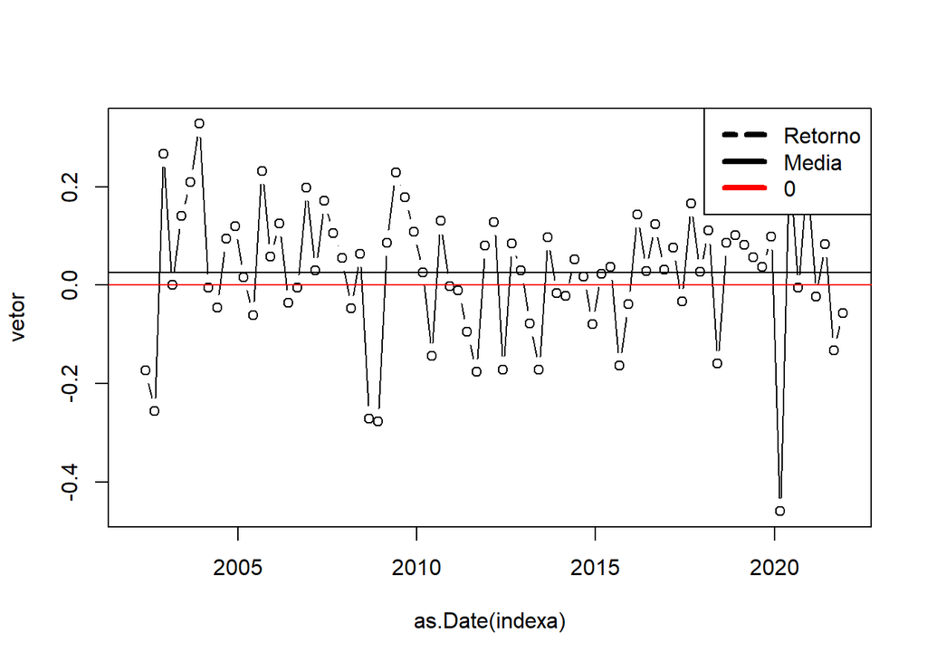

```r
vetor <- as.vector(baseLimpa[,'IBOV_dif'])
indexa <- index(baseLimpa[,'IBOV_dif'])
plot(as.Date(indexa),vetor,type="b")
par(mfrow=c(1,1))
abline(h=0,col="red")
abline(h=mean(na.omit(vetor)),col="black")
legend(x = "topright",         # Position
       legend = c("Retorno", "Media","0"), # Legend texts
       lty = c(6, 1 , 1),          # Line types
       col = c("Black", "Black","Red"),          # Line colors
       lwd = 4)
```

Criando um modelo generalista para testar variaveis

```r
model0TodosAgregados <- lm(IBOV_dif ~ .,data=baseLimpa)
summary(model0TodosAgregados)
```

```
##
## Call:
## lm(formula = IBOV_dif ~ ., data = baseLimpa)
##
## Residuals:
##      Min       1Q   Median       3Q      Max
## -0.47205 -0.03436  0.02019  0.07169  0.22404
##
## Coefficients:
##                                 Estimate Std. Error t value Pr(>|t|)
## (Intercept)                     0.025949   0.028428   0.913  0.36519
## commoditi_dif                  -0.110809   0.241646  -0.459  0.64829
## desemprego_dif                  0.234242   0.190470   1.230  0.22382
## igp_dif                        -1.450810   1.177287  -1.232  0.22288
## Agreg_Monetario1                2.287353   2.066869   1.107  0.27308
## Agreg_Monetario2                0.764711   0.849987   0.900  0.37208
## Agreg_Monetario3               -1.884723   2.848577  -0.662  0.51087
## producao_fisica_industrial_dif  0.636689   0.235269   2.706  0.00896 **
## jurosEUA_log                    0.009567   0.013035   0.734  0.46596
## RMM                             0.017359   0.035275   0.492  0.62452
## ibov_ontem                     -0.065387   0.140727  -0.465  0.64396
## gap                            -0.475413   0.467492  -1.017  0.31348
## ---
## Signif. codes:  0 '***' 0.001 '**' 0.01 '*' 0.05 '.' 0.1 ' ' 1
##
## Residual standard error: 0.1229 on 57 degrees of freedom
##   (11 observations deleted due to missingness)
## Multiple R-squared:  0.2885, Adjusted R-squared:  0.1512
## F-statistic: 2.101 on 11 and 57 DF,  p-value: 0.03481
```

Nessa hora fiz uma simulação de modelos, basicamente foi simulado todos os modelos possiveis (2047) e armazenando o R2 Ajustado. Peguei o modelo com maior para dar sequencia aos testes

```r
variaveis_possiveis <- colnames(baseLimpa)[-1]
n <- length(variaveis_possiveis)
l <- rep(list(0:1), n)
todas_regressoes <- expand.grid(l)
colnames(todas_regressoes) <- variaveis_possiveis
todas_regressoes <- todas_regressoes[-1,]
vetor_R2_Adj <- c()
for (regre in 1:dim(todas_regressoes)[1]){
  variaveis <- variaveis_possiveis[as.logical(as.vector(as.matrix(todas_regressoes[regre,])))]
  frm <- as.formula(paste0("IBOV_dif", "~", paste(variaveis, collapse = " + ")))
  reg <- lm(frm, data=baseLimpa)
  R2 <- summary(reg)$adj.r.squared
  vetor_R2_Adj <- c(vetor_R2_Adj, R2)
}
```

Graficos do R2 ajustado, com destaque ao valor 0

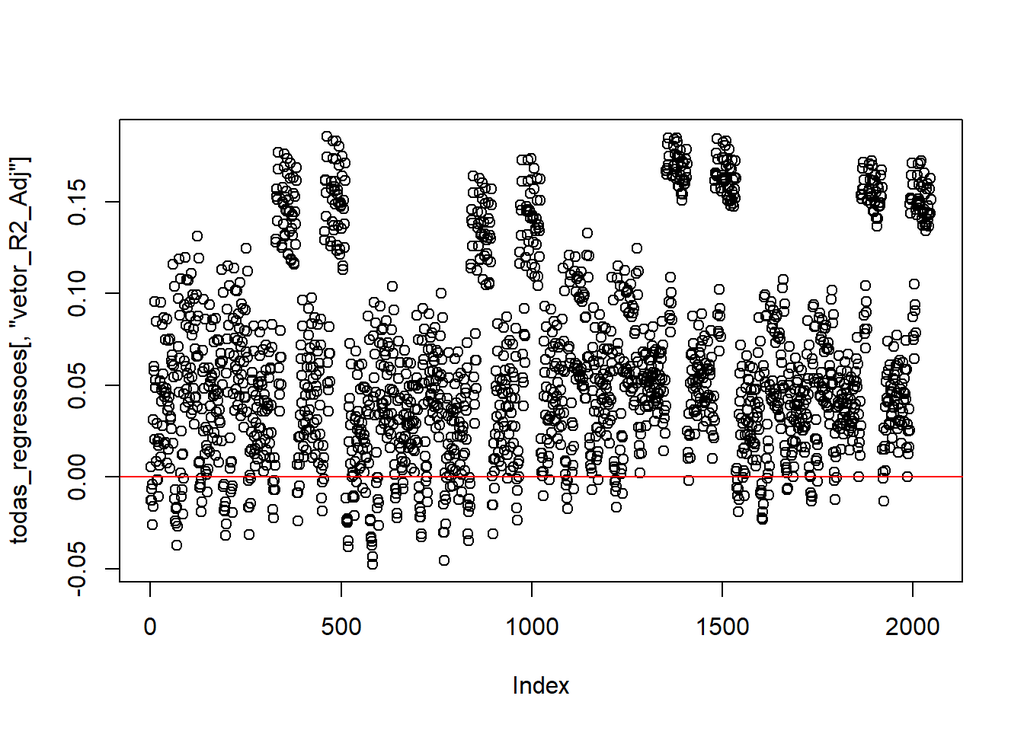

```r
todas_regressoes <- cbind(todas_regressoes, vetor_R2_Adj)

plot(todas_regressoes[,"vetor_R2_Adj"])
abline(h=0,col="red")
```

Melhor regressão modelo maximizando R2 ajustado

```r
## Melhor regressão modelo maximizando R2 ajustado
melhor <- todas_regressoes[which.max(todas_regressoes[,"vetor_R2_Adj"]),]
variaveis <- variaveis_possiveis[as.logical(as.vector(as.matrix(melhor)))]
variaveis <- variaveis[-7]
frm <- as.formula(paste("IBOV_dif","~", paste(variaveis,collapse = " + ")  ,sep=""))
reg <- lm(frm, data=baseLimpa)
summary(reg)
```

```
##
## Call:
## lm(formula = frm, data = baseLimpa)
##
## Residuals:
##      Min       1Q   Median       3Q      Max
## -0.42107 -0.05545  0.02770  0.07332  0.21198
##
## Coefficients:
##                                Estimate Std. Error t value Pr(>|t|)
## (Intercept)                     0.03020    0.02356   1.282  0.20460
## desemprego_dif                  0.30544    0.16692   1.830  0.07208 .
## igp_dif                        -1.76450    1.04396  -1.690  0.09601 .
## Agreg_Monetario1                1.13807    0.29861   3.811  0.00032 ***
## producao_fisica_industrial_dif  0.62717    0.22353   2.806  0.00670 **
## jurosEUA_log                    0.01460    0.01135   1.287  0.20302
## RMM                             0.01153    0.03255   0.354  0.72432
## ---
## Signif. codes:  0 '***' 0.001 '**' 0.01 '*' 0.05 '.' 0.1 ' ' 1
##
## Residual standard error: 0.1204 on 62 degrees of freedom
##   (11 observations deleted due to missingness)
## Multiple R-squared:  0.2573, Adjusted R-squared:  0.1854
## F-statistic: 3.579 on 6 and 62 DF,  p-value: 0.004138
```

Nessa hora, descobri que existe um modelo chamado forward/backward stepping model selection, fui testar fazer com de achar um modelo otimo.

```r
## Falhando com o forward / backward-stepping
baseLimpafwbw <- coredata(baseLimpa)
response <- baseLimpafwbw[,"IBOV_dif"]
baseLimpafwbw <- baseLimpafwbw[,-1]
fit <- lm(response ~ ., as.data.frame(baseLimpafwbw), x = TRUE, y = TRUE)
fwbw(fit,fun=AIC,fw=FALSE)
```

```
## $object
##
## Call:
## stats::lm(formula = object$y ~ ., data = as.data.frame(as.matrix(X_mu)),
##     x = TRUE, y = TRUE)
##
## Coefficients:
##                    (Intercept)                  desemprego_dif
##                        0.03156                         0.29987
##                        igp_dif                Agreg_Monetario1
##                       -1.76188                         1.13308
## producao_fisica_industrial_dif                    jurosEUA_log
##                        0.63013                         0.01644
##
##
## $fun
## [1] -89.57119
```

```r
regfwbw <- lm(IBOV_dif ~ desemprego_dif + igp_dif + Agreg_Monetario1 + producao_fisica_industrial_dif + jurosEUA_log,data=baseLimpa)
summary(regfwbw)
```

```
##
## Call:
## lm(formula = IBOV_dif ~ desemprego_dif + igp_dif + Agreg_Monetario1 +
##     producao_fisica_industrial_dif + jurosEUA_log, data = baseLimpa)
##
## Residuals:
##      Min       1Q   Median       3Q      Max
## -0.45051 -0.06204  0.03195  0.07152  0.28347
##
## Coefficients:
##                                Estimate Std. Error t value Pr(>|t|)
## (Intercept)                     0.01831    0.02135   0.857  0.39405
## desemprego_dif                  0.27533    0.16840   1.635  0.10636
## igp_dif                        -0.38270    0.64960  -0.589  0.55759
## Agreg_Monetario1                0.79775    0.26817   2.975  0.00397 **
## producao_fisica_industrial_dif  0.27061    0.21315   1.270  0.20826
## jurosEUA_log                    0.01116    0.01026   1.088  0.28011
## ---
## Signif. codes:  0 '***' 0.001 '**' 0.01 '*' 0.05 '.' 0.1 ' ' 1
##
## Residual standard error: 0.1327 on 73 degrees of freedom
##   (1 observation deleted due to missingness)
## Multiple R-squared:  0.1269, Adjusted R-squared:  0.06714
## F-statistic: 2.123 on 5 and 73 DF,  p-value: 0.07219
```

Na hora que rodei com as variaveis que ele ensinuou, o modelo foi pior ao que eu tinha, por isso foi discartado.

Tentei por hora até misturar os dois para ver se conseguia algo melhor, não consegui.

```r
## Misturar os dois
regfwbw2 <- lm(IBOV_dif ~ desemprego_dif + igp_dif + Agreg_Monetario1 + producao_fisica_industrial_dif,data=baseLimpa)
summary(regfwbw2)
```

```
##
## Call:
## lm(formula = IBOV_dif ~ desemprego_dif + igp_dif + Agreg_Monetario1 +
##     producao_fisica_industrial_dif, data = baseLimpa)
##
## Residuals:
##      Min       1Q   Median       3Q      Max
## -0.44606 -0.05464  0.01916  0.06795  0.27123
##
## Coefficients:
##                                Estimate Std. Error t value Pr(>|t|)
## (Intercept)                     0.01183    0.02053   0.576  0.56627
## desemprego_dif                  0.26555    0.16837   1.577  0.11902
## igp_dif                        -0.45281    0.64720  -0.700  0.48634
## Agreg_Monetario1                0.81334    0.26811   3.034  0.00333 **
## producao_fisica_industrial_dif  0.29818    0.21190   1.407  0.16356
## ---
## Signif. codes:  0 '***' 0.001 '**' 0.01 '*' 0.05 '.' 0.1 ' ' 1
##
## Residual standard error: 0.1328 on 74 degrees of freedom
##   (1 observation deleted due to missingness)
## Multiple R-squared:  0.1128, Adjusted R-squared:  0.06482
## F-statistic: 2.352 on 4 and 74 DF,  p-value: 0.06179
```

```r
#Não gostei, o primeiro vai ser o modelo
```

Com isso a regressão mensal passou a ser a do melhor R2 encontrada na simulação

```r
regGapMensal <- reg
summary(regGapMensal)
```

```
##
## Call:
## lm(formula = frm, data = baseLimpa)
##
## Residuals:
##      Min       1Q   Median       3Q      Max
## -0.42107 -0.05545  0.02770  0.07332  0.21198
##
## Coefficients:
##                                Estimate Std. Error t value Pr(>|t|)
## (Intercept)                     0.03020    0.02356   1.282  0.20460
## desemprego_dif                  0.30544    0.16692   1.830  0.07208 .
## igp_dif                        -1.76450    1.04396  -1.690  0.09601 .
## Agreg_Monetario1                1.13807    0.29861   3.811  0.00032 ***
## producao_fisica_industrial_dif  0.62717    0.22353   2.806  0.00670 **
## jurosEUA_log                    0.01460    0.01135   1.287  0.20302
## RMM                             0.01153    0.03255   0.354  0.72432
## ---
## Signif. codes:  0 '***' 0.001 '**' 0.01 '*' 0.05 '.' 0.1 ' ' 1
##
## Residual standard error: 0.1204 on 62 degrees of freedom
##   (11 observations deleted due to missingness)
## Multiple R-squared:  0.2573, Adjusted R-squared:  0.1854
## F-statistic: 3.579 on 6 and 62 DF,  p-value: 0.004138
```

Rodando um anova

```r
anova(regGapMensal)
```

|  | Df | Sum Sq | Mean Sq | F value | Pr(>F) |
| --- | --- | --- | --- | --- | --- |
| desemprego_dif | 1 | 0.001023812 | 0.001023812 | 0.07063261 | 0.791299689 |
| igp_dif | 1 | 0.036976209 | 0.036976209 | 2.55098294 | 0.115310413 |
| Agreg_Monetario1 | 1 | 0.102636113 | 0.102636113 | 7.08084946 | 0.009907174 |
| producao_fisica_industrial_dif | 1 | 0.130345110 | 0.130345110 | 8.99248889 | 0.003898320 |
| jurosEUA_log | 1 | 0.038505088 | 0.038505088 | 2.65646000 | 0.108200653 |
| RMM | 1 | 0.001819535 | 0.001819535 | 0.12552946 | 0.724315235 |
| Residuals | 62 | 0.898682993 | 0.014494887 | NA | NA |

Vi algumas inconsistencia, por isso fui testar modelo restrito só com variaveis singificativas

```r
ModeloIrrestrito <- lm(IBOV_dif ~ desemprego_dif + igp_dif + Agreg_Monetario1 + producao_fisica_industrial_dif +
    jurosEUA_log + RMM,data=na.omit(baseLimpa))
modeloRestrito <- lm(IBOV_dif ~ Agreg_Monetario1 + producao_fisica_industrial_dif,data=na.omit(baseLimpa))

anova(modeloRestrito,ModeloIrrestrito)
```

|  | Res.Df | RSS | Df | Sum of Sq | F | Pr(>F) |
| --- | --- | --- | --- | --- | --- | --- |
| 1 | 66 | 1.016773 | NA | NA | NA | NA |
| 2 | 62 | 0.898683 | 4 | 0.1180899 | 2.036752 | 0.1001508 |

Com isso o modelo restrito já pareceu melhor

```r
anova(model0TodosAgregados)
```

|  | Df | Sum Sq | Mean Sq | F value | Pr(>F) |
| --- | --- | --- | --- | --- | --- |
| commoditi_dif | 1 | 0.0009641733 | 0.0009641733 | 0.06383803 | 0.80143845 |
| desemprego_dif | 1 | 0.0012605686 | 0.0012605686 | 0.08346239 | 0.77370709 |
| igp_dif | 1 | 0.0374821278 | 0.0374821278 | 2.48169597 | 0.12071256 |
| Agreg_Monetario1 | 1 | 0.1022504276 | 0.1022504276 | 6.77001253 | 0.01179206 |
| Agreg_Monetario2 | 1 | 0.0226413237 | 0.0226413237 | 1.49908463 | 0.22584867 |
| Agreg_Monetario3 | 1 | 0.0208175968 | 0.0208175968 | 1.37833547 | 0.24526689 |
| producao_fisica_industrial_dif | 1 | 0.1205801876 | 0.1205801876 | 7.98362803 | 0.00649613 |
| jurosEUA_log | 1 | 0.0229816383 | 0.0229816383 | 1.52161691 | 0.22243750 |
| RMM | 1 | 0.0007702394 | 0.0007702394 | 0.05099764 | 0.82214410 |
| ibov_ontem | 1 | 0.0037253552 | 0.0037253552 | 0.24665619 | 0.62134950 |

[output cut: 2 more lines]

Ou seja, modelo Restrito foi melhor, ele passará a ser o nosso novo modelo E rodando um anova para a primeira regressão, com todas as variaveis, dava igualmente o resultado, ou seja, tudo foi “atoa”, podiamos ter só rodado um anova no teste inicial

```r
modeloRestritoSemAlfa <- lm(IBOV_dif ~ Agreg_Monetario1 + producao_fisica_industrial_dif - 1 ,data=na.omit(baseLimpa))
summary(modeloRestritoSemAlfa)
```

```
##
## Call:
## lm(formula = IBOV_dif ~ Agreg_Monetario1 + producao_fisica_industrial_dif -
##     1, data = na.omit(baseLimpa))
##
## Residuals:
##      Min       1Q   Median       3Q      Max
## -0.41887 -0.05094  0.01676  0.07506  0.22790
##
## Coefficients:
##                                Estimate Std. Error t value Pr(>|t|)
## Agreg_Monetario1                 0.8298     0.2101   3.950  0.00019 ***
## producao_fisica_industrial_dif   0.7284     0.2176   3.347  0.00134 **
## ---
## Signif. codes:  0 '***' 0.001 '**' 0.01 '*' 0.05 '.' 0.1 ' ' 1
##
## Residual standard error: 0.1234 on 67 degrees of freedom
## Multiple R-squared:  0.2008, Adjusted R-squared:  0.1769
## F-statistic: 8.417 on 2 and 67 DF,  p-value: 0.0005482
```

Por fim testamos tirar o alfa, pois segundo as finanças o retorno medio de um ativo tende a ser 0

```r
anova(modeloRestrito,modeloRestritoSemAlfa)
```

|  | Res.Df | RSS | Df | Sum of Sq | F | Pr(>F) |
| --- | --- | --- | --- | --- | --- | --- |
| 1 | 66 | 1.016773 | NA | NA | NA | NA |
| 2 | 67 | 1.019671 | -1 | -0.002897731 | 0.1880954 | 0.6659209 |

melhorou o modelo.

```r
regGapMensal <- modeloRestritoSemAlfa
summary(regGapMensal)
```

```
##
## Call:
## lm(formula = IBOV_dif ~ Agreg_Monetario1 + producao_fisica_industrial_dif -
##     1, data = na.omit(baseLimpa))
##
## Residuals:
##      Min       1Q   Median       3Q      Max
## -0.41887 -0.05094  0.01676  0.07506  0.22790
##
## Coefficients:
##                                Estimate Std. Error t value Pr(>|t|)
## Agreg_Monetario1                 0.8298     0.2101   3.950  0.00019 ***
## producao_fisica_industrial_dif   0.7284     0.2176   3.347  0.00134 **
## ---
## Signif. codes:  0 '***' 0.001 '**' 0.01 '*' 0.05 '.' 0.1 ' ' 1
##
## Residual standard error: 0.1234 on 67 degrees of freedom
## Multiple R-squared:  0.2008, Adjusted R-squared:  0.1769
## F-statistic: 8.417 on 2 and 67 DF,  p-value: 0.0005482
```

Ou seja, com essas mudanças, a regressão dos dados mensais passou a ser o modelo restrito sem alfa

Apartir daqui é uma sequencia de testes, por terem sidos tratados no documento, não irei citar um a um

Reset

```r
reset(regGapMensal)
```

```
##
##  RESET test
##
## data:  regGapMensal
## RESET = 0.47471, df1 = 2, df2 = 65, p-value = 0.6242
```

VIF

```r
vif(regGapMensal)
```

```
##               Agreg_Monetario1 producao_fisica_industrial_dif
##                       1.654051                       1.654051
```

Outliers

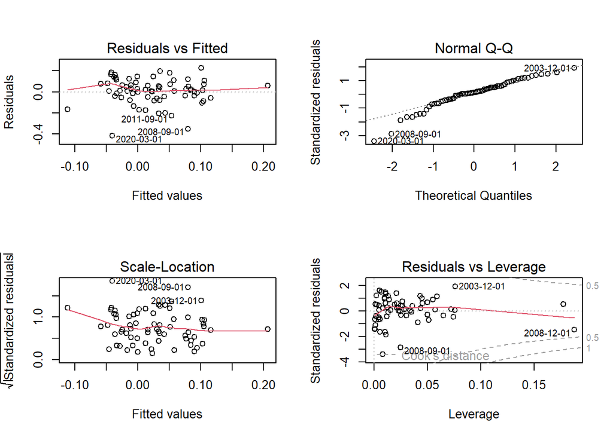

```r
par(mfrow=c(2,2))
plot(regGapMensal)
```

```r
par(mfrow=c(1,1))
```

Vendo os valores que são 3x maior que a media

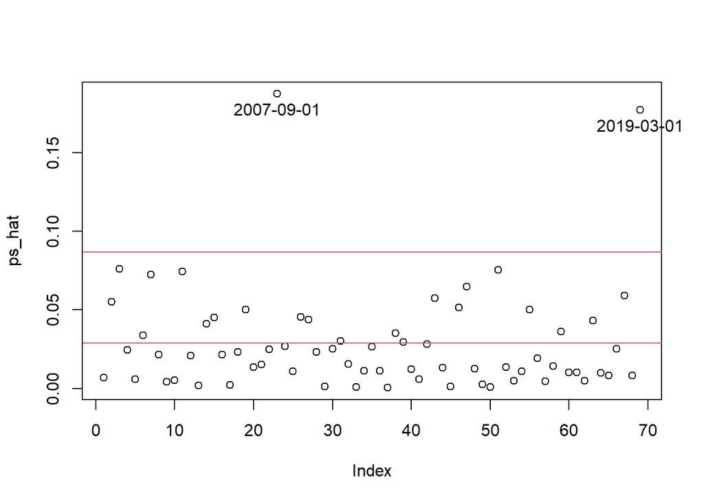

```r
ps_hat <- hatvalues(regGapMensal)
plot(ps_hat)
abline(h=c(1,3)*mean(ps_hat), col=2)
id <- which(ps_hat>3 * mean(ps_hat))
text(id, ps_hat[id], index(baseLimpa)[id], pos=1, xpd=TRUE)
```

Testes de diagnóstico:

```r
summary(influence.measures(regGapMensal))
```

```
## Potentially influential observations of
##   lm(formula = IBOV_dif ~ Agreg_Monetario1 + producao_fisica_industrial_dif -      1, data = na.omit(baseLimpa)) :
##
##            dfb.A_M1 dfb.p___ dffit   cov.r   cook.d hat
## 2003-12-01  0.50     0.10     0.56_*  1.00    0.15   0.08
## 2004-12-01  0.04     0.01     0.04    1.11_*  0.00   0.07
## 2005-12-01 -0.13    -0.05    -0.14    1.11_*  0.01   0.07
## 2008-09-01 -0.46    -0.41    -0.49    0.81_*  0.11   0.02
## 2008-12-01  0.19     0.66    -0.72_*  1.19_*  0.25   0.19_*
## 2013-12-01  0.00    -0.02     0.03    1.09_*  0.00   0.06
## 2014-12-01  0.00     0.07    -0.09    1.10_*  0.00   0.06
## 2015-12-01  0.00    -0.01     0.02    1.11_*  0.00   0.08
## 2020-03-01  0.33     0.16    -0.34    0.71_*  0.05   0.01
## 2020-06-01  0.24     0.15     0.24    1.24_*  0.03   0.18_*
```

teste de jarqueberaTest

```r
e <- resid(regGapMensal)
jarqueberaTest(e)
```

```
##
## Title:
##  Jarque - Bera Normalality Test
##
## Test Results:
##   STATISTIC:
##     X-squared: 18.6343
##   P VALUE:
##     Asymptotic p Value: 8.987e-05
##
## Description:
##  Thu Nov 24 22:55:33 2022 by user: diogo
```

Teste de Breusch-Pagan:

```r
bptest(regGapMensal)
```

```
##
##  studentized Breusch-Pagan test
##
## data:  regGapMensal
## BP = 0.54321, df = 1, p-value = 0.4611
```

Teste de White

```r
white(regGapMensal, interactions = TRUE)
```

```
## Intercept included in auxiliary design matrix
```

| statistic | p.value | parameter | method | alternative |
| --- | --- | --- | --- | --- |
| 4.166924 | 0.525642 | 5 | White's Test | greater |

Teste de Goldfeld e Quandt

```r
gqtest(regGapMensal, data=baseLimpa)
```

```
##
##  Goldfeld-Quandt test
##
## data:  regGapMensal
## GQ = 0.94248, df1 = 33, df2 = 32, p-value = 0.5672
## alternative hypothesis: variance increases from segment 1 to 2
```

Matriz de covariância de White:

```r
vcovHC(regGapMensal)
```

```
##                                Agreg_Monetario1 producao_fisica_industrial_dif
## Agreg_Monetario1                     0.04200690                     0.03036972
## producao_fisica_industrial_dif       0.03036972                     0.04806397
```

Ver correlacao serial

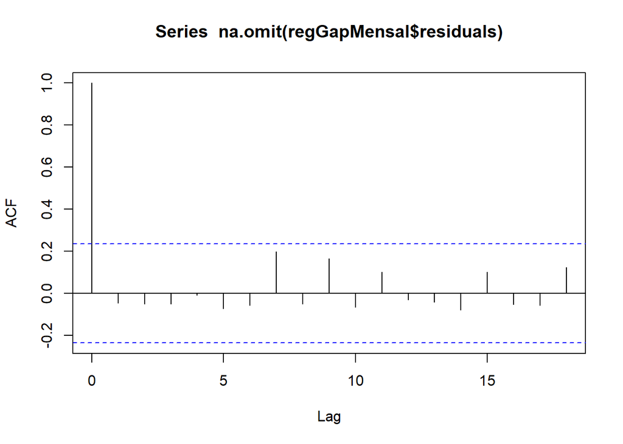

```r
acf(na.omit(regGapMensal$residuals), plot = T)
```

Teste de Durbin-Watson

```r
dwtest(regGapMensal)
```

```
##
##  Durbin-Watson test
##
## data:  regGapMensal
## DW = 2.0524, p-value = 0.6459
## alternative hypothesis: true autocorrelation is greater than 0
```

Por fim foi feita uma tentativa de ver dummys de governo, não muito bem sucedida

```r
indexBase <- index(baseLimpa)
dummys <- matrix(0,nrow = length(indexBase))
rownames(dummys) <- indexBase
dummys <- cbind(dummys,0)
colnames(dummys) <- c("Governo_Esquerda","Governo_Direita")
dummys[rownames(dummys) > as.Date("2002-02-01") & rownames(dummys) < as.Date("2016-08-31"),"Governo_Esquerda"] <- 1
dummys[rownames(dummys) > as.Date("2016-08-31"),"Governo_Direita"] <- 1
dummys <- zoo(dummys,order.by = rownames(dummys))
baseLimpaGoverno <- cbind(baseLimpa,dummys)
modeloGoverno <- lm(IBOV_dif ~ Agreg_Monetario1 + producao_fisica_industrial_dif + Governo_Esquerda + Governo_Direita - 1
  ,data=na.omit(baseLimpaGoverno))
```

Dummy pandemia, também não mt bem sucedida

```r
indexBase <- index(baseLimpa)
dummys <- matrix(0,nrow = length(indexBase))
rownames(dummys) <- indexBase
colnames(dummys) <- c("Pandemia")
dummys[rownames(dummys) > as.Date("2020-03-01") & rownames(dummys) < as.Date("2021-01-01"),"Pandemia"] <- 1
dummys <- zoo(dummys,order.by = rownames(dummys))
baseLimpaPandemia <- cbind(baseLimpa,dummys)
modeloPandemia <- lm(IBOV_dif ~ Agreg_Monetario1 + producao_fisica_industrial_dif + Pandemia - 1
  ,data=na.omit(baseLimpaPandemia))
summary(modeloPandemia)
```

```
##
## Call:
## lm(formula = IBOV_dif ~ Agreg_Monetario1 + producao_fisica_industrial_dif +
##     Pandemia - 1, data = na.omit(baseLimpaPandemia))
##
## Residuals:
##      Min       1Q   Median       3Q      Max
## -0.42147 -0.04985  0.01856  0.07857  0.23496
##
## Coefficients:
##                                Estimate Std. Error t value Pr(>|t|)
## Agreg_Monetario1                0.77977    0.23290   3.348  0.00135 **
## producao_fisica_industrial_dif  0.69497    0.22843   3.042  0.00337 **
## Pandemia                        0.06972    0.13677   0.510  0.61194
## ---
## Signif. codes:  0 '***' 0.001 '**' 0.01 '*' 0.05 '.' 0.1 ' ' 1
##
## Residual standard error: 0.1241 on 66 degrees of freedom
## Multiple R-squared:  0.2039, Adjusted R-squared:  0.1677
## F-statistic: 5.636 on 3 and 66 DF,  p-value: 0.001682
```

Tratando Outliers: Criterio: 2 ou mais sinalizações no testes de diagnosticos

```r
indexBase <- index(baseLimpa)
dummys <- matrix(0,nrow = length(indexBase))
rownames(dummys) <- indexBase
dummys <- cbind(dummys,0)
colnames(dummys) <- c("2020-06-01","2008-12-01")
dummys[rownames(dummys) == as.Date("2020-06-01"),"2020-06-01"] <- 1
dummys[rownames(dummys) == as.Date("2008-12-01"),"2008-12-01"] <- 1
dummys <- zoo(dummys,order.by = rownames(dummys))
baseLimpaOutliers <- cbind(baseLimpa,dummys)
baseLimpaOutliers <- na.omit(baseLimpaOutliers)
modeloOutliers <- lm(IBOV_dif ~ Agreg_Monetario1 + producao_fisica_industrial_dif + baseLimpaOutliers[,"2020-06-01"]
  + baseLimpaOutliers[,"2008-12-01"] - 1 ,data=baseLimpaOutliers)
summary(modeloOutliers)
```

```
##
## Call:
## lm(formula = IBOV_dif ~ Agreg_Monetario1 + producao_fisica_industrial_dif +
##     baseLimpaOutliers[, "2020-06-01"] + baseLimpaOutliers[, "2008-12-01"] -
##     1, data = baseLimpaOutliers)
##
## Residuals:
##      Min       1Q   Median       3Q      Max
## -0.42250 -0.04951  0.02083  0.08264  0.23057
##
## Coefficients:
##                                   Estimate Std. Error t value Pr(>|t|)
## Agreg_Monetario1                   0.73059    0.23284   3.138  0.00256 **
## producao_fisica_industrial_dif     0.54328    0.24706   2.199  0.03144 *
## baseLimpaOutliers[, "2020-06-01"]  0.08265    0.13568   0.609  0.54457
## baseLimpaOutliers[, "2008-12-01"] -0.20830    0.13653  -1.526  0.13194
## ---
## Signif. codes:  0 '***' 0.001 '**' 0.01 '*' 0.05 '.' 0.1 ' ' 1
##
## Residual standard error: 0.1228 on 65 degrees of freedom
## Multiple R-squared:  0.2315, Adjusted R-squared:  0.1842
## F-statistic: 4.894 on 4 and 65 DF,  p-value: 0.00164
```

```r
stargazer(model0TodosAgregados,regGapMensal,modeloOutliers,type="text",
          column.labels = c("Modelo Geral","Modelo Restrito","Modelo Restrito Sem Outliers"),
          title = "GAP Trimestral")
```

```
##
## GAP Trimestral
## ==========================================================================================================
##                                                             Dependent variable:
##                                   ------------------------------------------------------------------------
##                                                                   IBOV_dif
##                                       Modelo Geral         Modelo Restrito    Modelo Restrito Sem Outliers
##                                            (1)                   (2)                      (3)
## ----------------------------------------------------------------------------------------------------------
## commoditi_dif                            -0.111
##                                          (0.242)
##
## desemprego_dif                            0.234
##                                          (0.190)
##
## igp_dif                                  -1.451
##                                          (1.177)
##
## Agreg_Monetario1                          2.287               0.830***                  0.731***
##                                          (2.067)               (0.210)                  (0.233)
##
## Agreg_Monetario2                          0.765
##                                          (0.850)
##
## Agreg_Monetario3                         -1.885
##                                          (2.849)
##
## producao_fisica_industrial_dif          0.637***              0.728***                  0.543**
##                                          (0.235)               (0.218)                  (0.247)
##
## jurosEUA_log                              0.010
##                                          (0.013)
##
## RMM                                       0.017
##                                          (0.035)
##
## ibov_ontem                               -0.065
##                                          (0.141)
##
## gap                                      -0.475
##                                          (0.467)
##
## baseLimpaOutliers[, "2020-06-01"]                                                        0.083
##                                                                                         (0.136)
##
## baseLimpaOutliers[, "2008-12-01"]                                                        -0.208
##                                                                                         (0.137)
##
## Constant                                  0.026
##                                          (0.028)
##
## ----------------------------------------------------------------------------------------------------------
## Observations                               69                    69                        69
## R2                                        0.289                 0.201                    0.231
## Adjusted R2                               0.151                 0.177                    0.184
## Residual Std. Error                  0.123 (df = 57)       0.123 (df = 67)          0.123 (df = 65)
## F Statistic                       2.101** (df = 11; 57) 8.417*** (df = 2; 67)    4.894*** (df = 4; 65)
## ==========================================================================================================
## Note:                                                                          *p<0.1; **p<0.05; ***p<0.01
```

```r
stargazer(model0TodosAgregados,regGapMensal,modeloOutliers,type="text")
```

```
##
## ===================================================================================================
##                                                          Dependent variable:
##                                   -----------------------------------------------------------------
##                                                               IBOV_dif
##                                            (1)                   (2)                   (3)
## ---------------------------------------------------------------------------------------------------
## commoditi_dif                            -0.111
##                                          (0.242)
##
## desemprego_dif                            0.234
##                                          (0.190)
##
## igp_dif                                  -1.451
##                                          (1.177)
##
## Agreg_Monetario1                          2.287               0.830***              0.731***
##                                          (2.067)               (0.210)               (0.233)
##
## Agreg_Monetario2                          0.765
##                                          (0.850)
##
## Agreg_Monetario3                         -1.885
##                                          (2.849)
##
## producao_fisica_industrial_dif          0.637***              0.728***               0.543**
##                                          (0.235)               (0.218)               (0.247)
##
## jurosEUA_log                              0.010
##                                          (0.013)
##
## RMM                                       0.017
##                                          (0.035)
##
## ibov_ontem                               -0.065
##                                          (0.141)
##
## gap                                      -0.475
##                                          (0.467)
##
## baseLimpaOutliers[, "2020-06-01"]                                                     0.083
##                                                                                      (0.136)
##
## baseLimpaOutliers[, "2008-12-01"]                                                    -0.208
##                                                                                      (0.137)
##
## Constant                                  0.026
##                                          (0.028)
##
## ---------------------------------------------------------------------------------------------------
## Observations                               69                    69                    69
## R2                                        0.289                 0.201                 0.231
## Adjusted R2                               0.151                 0.177                 0.184
## Residual Std. Error                  0.123 (df = 57)       0.123 (df = 67)       0.123 (df = 65)
## F Statistic                       2.101** (df = 11; 57) 8.417*** (df = 2; 67) 4.894*** (df = 4; 65)
## ===================================================================================================
## Note:                                                                   *p<0.1; **p<0.05; ***p<0.01
```

# Modelo Mensal por replicação do GAP

Reconstruindo a base de dados para GAP não mensal

```r
baseDadosMensalFill <- baseDados
baseDadosMensalFill <- na.locf(baseDadosMensalFill)
baseDadosMensalFill <- na.omit(baseDadosMensalFill)

#A primeira diferença do logaritmo do retorno real da bolsa de valores de São Paulo (RSR);
ibov_dif <- zoo(primeiradiferencalog(baseDadosMensalFill[,"ibov"]))

#ibovespa de ontem
ibov_ontem <- ibov_dif
ibov_ontem_index <- index(ibov_ontem)
ibov_ontem <- as_tibble(ibov_ontem)
ibov_ontem <- ibov_ontem%>%dplyr::mutate(growth_lag1 = dplyr::lag(ibov_ontem))
ibov_ontem <- zoo(ibov_ontem[,2],order.by = ibov_ontem_index)

#a primeira diferença do logaritmo dos preços das Commodities (COM);
commoditi_dif <- zoo(primeiradiferencalog(baseDadosMensalFill[,5]))
colnames(baseDadosMensalFill)[5]
```

```
## [1] "Índice.de.Commodities"
```

```r
#a primeira diferença do logaritmo do desemprego: antiga Pesquisa Mensal do Emprego - PME/ IBGE-19(DES);
desemprego_dif <- zoo(primeiradiferencalog(baseDadosMensalFill[,"desemprego"]))

#a primeira diferença do logaritmo do IGP (IGP);
igp_dif <- zoo(primeiradiferencalog(baseDadosMensalFill[,'1.IGPM']))

#a primeira diferença do logaritmo do agregado monetário M1(M1)
M1.1 <- zoo(primeiradiferencalog(baseDadosMensalFill[,1]))
M1.2 <- zoo(primeiradiferencalog(baseDadosMensalFill[,2]))
M1.3 <- zoo(primeiradiferencalog(baseDadosMensalFill[,3]))
colnames(baseDadosMensalFill)[c(1,2,3)]
```

```
## [1] "Papel.moeda.em.circulação" "Reservas.bancárias"
## [3] "Base.monetária.restrita"
```

```r
#a primeira diferença do logaritmo da produção física industrial dessazonalizada
producao_dif <- zoo(primeiradiferencalog(baseDadosMensalFill[,4]))

# o logaritmo da taxa de juros dos EUA (EUA).
juros_log <- log(baseDadosMensalFill[,'FedFunds'])

#o Relative Market Money Rate, construída através da diferença da taxa de juros e a média móvel de 12 meses para trás (RMM);
RMM <- baseDadosMensalFill[,'FedFunds'] - rollmean(baseDadosMensalFill[,'FedFunds'],12)

#gap
gap <- baseDadosMensalFill[,'gap']

baseDadosMensalFillLimpa <- merge.zoo(ibov_dif,commoditi_dif,desemprego_dif,igp_dif, M1.1, M1.2, M1.3, producao_dif, juros_log,RMM,ibov_ontem,gap)

colnames(baseDadosMensalFillLimpa) <- c("IBOV_dif","commoditi_dif","desemprego_dif","igp_dif","Agreg_Monetario1","Agreg_Monetario2","Agreg_Monetario3",
                                        "producao_fisica_industrial_dif","jurosEUA_log","RMM","ibov_ontem","gap")
```

Correlacao

```r
cor(na.omit(baseDadosMensalFillLimpa))
```

```
##                                     IBOV_dif commoditi_dif desemprego_dif
## IBOV_dif                        1.0000000000   -0.12536823  -0.0006254976
## commoditi_dif                  -0.1253682322    1.00000000  -0.1191571473
## desemprego_dif                 -0.0006254976   -0.11915715   1.0000000000
## igp_dif                        -0.0268439507    0.27945957   0.0073082044
## Agreg_Monetario1                0.1120274018    0.19386794  -0.6190209547
## Agreg_Monetario2                0.0804594113    0.07368604  -0.1942690383
## Agreg_Monetario3                0.1219127232    0.17254955  -0.5593157965
## producao_fisica_industrial_dif  0.0048188957   -0.01095344   0.2207348959
## jurosEUA_log                    0.0563994844   -0.09628773  -0.0735683246
## RMM                            -0.1281589552   -0.03979091  -0.0626476981
## ibov_ontem                      0.1060521074   -0.07099775  -0.0371972526
## gap                            -0.1374463798   -0.06784668  -0.1571444501
##                                     igp_dif Agreg_Monetario1 Agreg_Monetario2
## IBOV_dif                       -0.026843951      0.112027402       0.08045941
## commoditi_dif                   0.279459573      0.193867938       0.07368604
## desemprego_dif                  0.007308204     -0.619020955      -0.19426904
## igp_dif                         1.000000000      0.060349058       0.08685389
## Agreg_Monetario1                0.060349058      1.000000000       0.34073211
## Agreg_Monetario2                0.086853894      0.340732113       1.00000000
## Agreg_Monetario3                0.073448146      0.917732790       0.66634867
## producao_fisica_industrial_dif  0.001086623     -0.427980592      -0.03734617
## jurosEUA_log                   -0.095046819      0.012268499       0.03463877
## RMM                            -0.003155480     -0.040396190       0.06114774
## ibov_ontem                     -0.078667719      0.008810398       0.07572848
## gap                            -0.109631600      0.001793535      -0.05835512
##                                Agreg_Monetario3 producao_fisica_industrial_dif
## IBOV_dif                            0.121912723                    0.004818896
## commoditi_dif                       0.172549549                   -0.010953439
## desemprego_dif                     -0.559315796                    0.220734896
## igp_dif                             0.073448146                    0.001086623
## Agreg_Monetario1                    0.917732790                   -0.427980592
## Agreg_Monetario2                    0.666348673                   -0.037346170
## Agreg_Monetario3                    1.000000000                   -0.361719891
## producao_fisica_industrial_dif     -0.361719891                    1.000000000
## jurosEUA_log                        0.020045898                    0.022449161
## RMM                                -0.009075138                    0.090118586
## ibov_ontem                          0.022713784                    0.145675758
## gap                                -0.022228091                   -0.041300097
##                                jurosEUA_log          RMM   ibov_ontem
```

[output cut: 10 more lines]

```
## ibov_ontem                       0.11255557  0.046137568  1.000000000
## gap                             -0.07942791  0.115603614 -0.137052055
##                                         gap
## IBOV_dif                       -0.137446380
## commoditi_dif                  -0.067846680
## desemprego_dif                 -0.157144450
## igp_dif                        -0.109631600
## Agreg_Monetario1                0.001793535
## Agreg_Monetario2               -0.058355118
## Agreg_Monetario3               -0.022228091
## producao_fisica_industrial_dif -0.041300097
## jurosEUA_log                   -0.079427910
## RMM                             0.115603614
## ibov_ontem                     -0.137052055
## gap                             1.000000000
```

Modelo generalista

```r
modelFillTodos <- lm(IBOV_dif ~ .,data=baseDadosMensalFillLimpa)
summary(modelFillTodos)
```

```
##
## Call:
## lm(formula = IBOV_dif ~ ., data = baseDadosMensalFillLimpa)
##
## Residuals:
##      Min       1Q   Median       3Q      Max
## -0.38566 -0.03353 -0.00392  0.04065  0.19840
##
## Coefficients:
##                                 Estimate Std. Error t value Pr(>|t|)
## (Intercept)                     0.007941   0.006345   1.251   0.2121
## commoditi_dif                  -0.290063   0.128466  -2.258   0.0250 *
## desemprego_dif                  0.101673   0.107519   0.946   0.3454
## igp_dif                         0.023278   0.524551   0.044   0.9646
## Agreg_Monetario1                0.142242   0.720212   0.198   0.8436
## Agreg_Monetario2               -0.030909   0.251566  -0.123   0.9023
## Agreg_Monetario3                0.286318   0.945536   0.303   0.7623
## producao_fisica_industrial_dif  0.074382   0.076026   0.978   0.3290
## jurosEUA_log                    0.003159   0.003262   0.968   0.3339
## RMM                            -0.059562   0.029372  -2.028   0.0438 *
## ibov_ontem                      0.069969   0.067329   1.039   0.2999
## gap                            -0.193911   0.134773  -1.439   0.1517
## ---
## Signif. codes:  0 '***' 0.001 '**' 0.01 '*' 0.05 '.' 0.1 ' ' 1
##
## Residual standard error: 0.06824 on 215 degrees of freedom
##   (11 observations deleted due to missingness)
## Multiple R-squared:  0.08903,    Adjusted R-squared:  0.04242
## F-statistic:  1.91 on 11 and 215 DF,  p-value: 0.03939
```

Desta vez, já fui direto ao anova.

```r
anova(modelFillTodos)
```

|  | Df | Sum Sq | Mean Sq | F value | Pr(>F) |
| --- | --- | --- | --- | --- | --- |
| commoditi_dif | 1 | 1.727397e-02 | 1.727397e-02 | 3.709456987 | 0.05542381 |
| desemprego_dif | 1 | 2.700667e-04 | 2.700667e-04 | 0.057994834 | 0.80992321 |
| igp_dif | 1 | 9.317315e-05 | 9.317315e-05 | 0.020008243 | 0.88764651 |
| Agreg_Monetario1 | 1 | 2.931550e-02 | 2.931550e-02 | 6.295285922 | 0.01284376 |
| Agreg_Monetario2 | 1 | 2.146417e-03 | 2.146417e-03 | 0.460927108 | 0.49792117 |
| Agreg_Monetario3 | 1 | 2.903456e-05 | 2.903456e-05 | 0.006234956 | 0.93713650 |
| producao_fisica_industrial_dif | 1 | 5.731231e-03 | 5.731231e-03 | 1.230739300 | 0.26850264 |
| jurosEUA_log | 1 | 2.182021e-03 | 2.182021e-03 | 0.468572819 | 0.49438169 |
| RMM | 1 | 2.374178e-02 | 2.374178e-02 | 5.098372008 | 0.02495250 |
| ibov_ontem | 1 | 7.427233e-03 | 7.427233e-03 | 1.594943215 | 0.20798924 |

[output cut: 2 more lines]

Selecionando as variaveis que fizeram diferença

```r
modelMensalSimples <- lm(IBOV_dif ~ commoditi_dif + RMM + Agreg_Monetario1,data=baseDadosMensalFillLimpa)
summary(modelMensalSimples)
```

```
##
## Call:
## lm(formula = IBOV_dif ~ commoditi_dif + RMM + Agreg_Monetario1,
##     data = baseDadosMensalFillLimpa)
##
## Residuals:
##      Min       1Q   Median       3Q      Max
## -0.38186 -0.04095  0.00048  0.04462  0.19779
##
## Coefficients:
##                   Estimate Std. Error t value Pr(>|t|)
## (Intercept)       0.010912   0.004711   2.316   0.0214 *
## commoditi_dif    -0.289227   0.122442  -2.362   0.0190 *
## RMM              -0.054540   0.027638  -1.973   0.0497 *
## Agreg_Monetario1  0.238483   0.115546   2.064   0.0402 *
## ---
## Signif. codes:  0 '***' 0.001 '**' 0.01 '*' 0.05 '.' 0.1 ' ' 1
##
## Residual standard error: 0.06837 on 223 degrees of freedom
##   (11 observations deleted due to missingness)
## Multiple R-squared:  0.05159,    Adjusted R-squared:  0.03883
## F-statistic: 4.044 on 3 and 223 DF,  p-value: 0.007957
```

Melhorou a principio.

```r
modelMensalSimplesSemAlfa <- lm(IBOV_dif ~ Agreg_Monetario1 + commoditi_dif + RMM  - 1 ,data=baseDadosMensalFillLimpa)
summary(modelMensalSimplesSemAlfa)
```

```
##
## Call:
## lm(formula = IBOV_dif ~ Agreg_Monetario1 + commoditi_dif + RMM -
##     1, data = baseDadosMensalFillLimpa)
##
## Residuals:
##      Min       1Q   Median       3Q      Max
## -0.36845 -0.03078  0.00981  0.05288  0.20064
##
## Coefficients:
##                  Estimate Std. Error t value Pr(>|t|)
## Agreg_Monetario1  0.29537    0.11400   2.591   0.0102 *
## commoditi_dif    -0.25528    0.12274  -2.080   0.0387 *
## RMM              -0.05270    0.02789  -1.889   0.0601 .
## ---
## Signif. codes:  0 '***' 0.001 '**' 0.01 '*' 0.05 '.' 0.1 ' ' 1
##
## Residual standard error: 0.06903 on 224 degrees of freedom
##   (11 observations deleted due to missingness)
## Multiple R-squared:  0.05371,    Adjusted R-squared:  0.04103
## F-statistic: 4.238 on 3 and 224 DF,  p-value: 0.006151
```

Selecionando as variaveis que fizeram diferença, removendo o alfa pelo mesmo motivo da analise anterior.

```r
stargazer(modelMensalSimples,modelMensalSimplesSemAlfa,type="text",title="Comparando Modelo com e sem Alfa gap mensal")
```

```
##
## Comparando Modelo com e sem Alfa gap mensal
## =================================================================
##                                  Dependent variable:
##                     ---------------------------------------------
##                                       IBOV_dif
##                              (1)                    (2)
## -----------------------------------------------------------------
## commoditi_dif              -0.289**               -0.255**
##                            (0.122)                (0.123)
##
## RMM                        -0.055**               -0.053*
##                            (0.028)                (0.028)
##
## Agreg_Monetario1           0.238**                0.295**
##                            (0.116)                (0.114)
##
## Constant                   0.011**
##                            (0.005)
##
## -----------------------------------------------------------------
## Observations                 227                    227
## R2                          0.052                  0.054
## Adjusted R2                 0.039                  0.041
## Residual Std. Error    0.068 (df = 223)       0.069 (df = 224)
## F Statistic         4.044*** (df = 3; 223) 4.238*** (df = 3; 224)
## =================================================================
## Note:                                 *p<0.1; **p<0.05; ***p<0.01
```

O modelo mensal passou a ser o Sem o Alfa

```r
modelMensalSimples <- modelMensalSimplesSemAlfa

summary(modelMensalSimples)
```

```
##
## Call:
## lm(formula = IBOV_dif ~ Agreg_Monetario1 + commoditi_dif + RMM -
##     1, data = baseDadosMensalFillLimpa)
##
## Residuals:
##      Min       1Q   Median       3Q      Max
## -0.36845 -0.03078  0.00981  0.05288  0.20064
##
## Coefficients:
##                  Estimate Std. Error t value Pr(>|t|)
## Agreg_Monetario1  0.29537    0.11400   2.591   0.0102 *
## commoditi_dif    -0.25528    0.12274  -2.080   0.0387 *
## RMM              -0.05270    0.02789  -1.889   0.0601 .
## ---
## Signif. codes:  0 '***' 0.001 '**' 0.01 '*' 0.05 '.' 0.1 ' ' 1
##
## Residual standard error: 0.06903 on 224 degrees of freedom
##   (11 observations deleted due to missingness)
## Multiple R-squared:  0.05371,    Adjusted R-squared:  0.04103
## F-statistic: 4.238 on 3 and 224 DF,  p-value: 0.006151
```

Os testes, por serem os mesmos do modelo anterior, não será re-citado Teste reset

```r
reset(modelMensalSimples)
```

```
##
##  RESET test
##
## data:  modelMensalSimples
## RESET = 0.03579, df1 = 2, df2 = 222, p-value = 0.9648
```

```r
vif(modelMensalSimples)
```

```
## Agreg_Monetario1    commoditi_dif              RMM
##         1.054512         1.054603         1.002122
```

Graficos a serem analisados

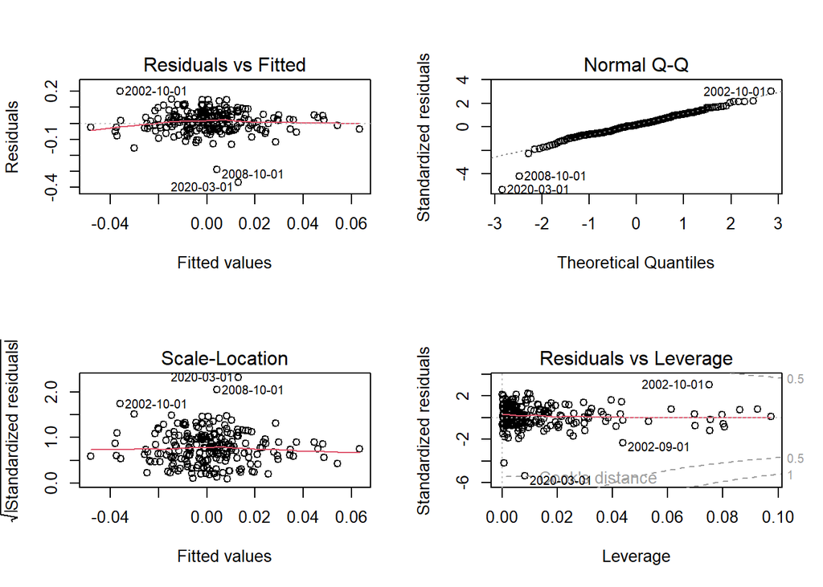

```r
par(mfrow=c(2,2))
plot(modelMensalSimples)
```

```r
par(mfrow=c(1,1))
```

Elementos da diagonal de H:

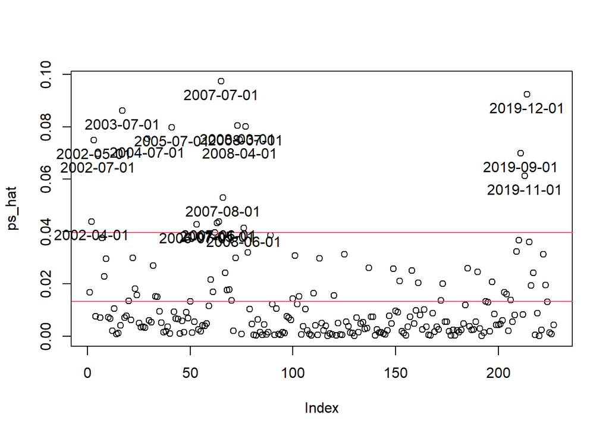

```r
ps_hat <- hatvalues(modelMensalSimples)
plot(ps_hat)
abline(h=c(1,3)*mean(ps_hat), col=2)
id <- which(ps_hat>3 * mean(ps_hat))
text(id, ps_hat[id], index(baseDadosMensalFillLimpa)[id], pos=1, xpd=TRUE)
```

Testes de diagnóstico:

```r
summary(influence.measures(modelMensalSimples))
```

```
## Potentially influential observations of
##   lm(formula = IBOV_dif ~ Agreg_Monetario1 + commoditi_dif + RMM -      1, data = baseDadosMensalFillLimpa) :
##
##            dfb.A_M1 dfb.cmm_ dfb.RMM dffit   cov.r   cook.d hat
## 2002-09-01 -0.02    -0.44    -0.21   -0.50_*  0.99    0.08   0.04_*
## 2002-10-01  0.07     0.78     0.35    0.88_*  0.97    0.25   0.07_*
## 2002-12-01  0.08     0.00    -0.02    0.09    1.09_*  0.00   0.07_*
## 2003-02-01  0.05    -0.06     0.01   -0.07    1.05_*  0.00   0.04
## 2003-12-01  0.22    -0.01     0.00    0.23    1.10_*  0.02   0.09_*
## 2004-05-01  0.00     0.01     0.00    0.01    1.04_*  0.00   0.03
## 2004-12-01 -0.05     0.02     0.00   -0.05    1.10_*  0.00   0.08_*
## 2005-02-01 -0.11    -0.08    -0.04    0.16    0.96_*  0.01   0.01
## 2005-12-01  0.07     0.02     0.00    0.08    1.10_*  0.00   0.08_*
## 2006-01-01 -0.19     0.11    -0.07    0.22    0.96_*  0.02   0.01
## 2006-12-01  0.07    -0.01     0.00    0.07    1.06_*  0.00   0.04_*
## 2007-10-01  0.04    -0.04     0.30    0.31    1.03    0.03   0.04_*
## 2007-11-01 -0.01     0.00    -0.05   -0.05    1.06_*  0.00   0.04_*
## 2007-12-01  0.02     0.00     0.02    0.02    1.12_*  0.00   0.10_*
## 2008-01-01  0.02    -0.03    -0.07   -0.08    1.07_*  0.00   0.05_*
## 2008-08-01 -0.05     0.12    -0.22   -0.25    1.09_*  0.02   0.08_*
## 2008-09-01 -0.04    -0.11    -0.32   -0.34    1.07_*  0.04   0.08_*
## 2008-10-01 -0.09    -0.03     0.05   -0.12    0.79_*  0.00   0.00
## 2008-11-01 -0.02     0.07     0.16   -0.17    1.05_*  0.01   0.04_*
## 2008-12-01 -0.10     0.04     0.13   -0.17    1.10_*  0.01   0.08_*
## 2009-01-01 -0.04     0.00    -0.09    0.09    1.04_*  0.00   0.03
## 2009-04-01  0.02    -0.03    -0.03    0.04    0.96_*  0.00   0.00
## 2009-12-01 -0.01     0.00     0.00   -0.01    1.05_*  0.00   0.04
## 2010-12-01  0.01     0.00     0.00    0.01    1.05_*  0.00   0.03
## 2011-12-01 -0.09     0.03     0.01   -0.09    1.04_*  0.00   0.03
## 2012-12-01  0.08    -0.01     0.01    0.08    1.04_*  0.00   0.03
## 2020-01-01 -0.01     0.01     0.05    0.05    1.05_*  0.00   0.04
## 2020-02-01  0.01     0.00    -0.20   -0.21    1.08_*  0.01   0.07_*
## 2020-03-01  0.04     0.43     0.28   -0.52_*  0.68_*  0.08   0.01
## 2020-04-01  0.07     0.00    -0.19    0.20    1.07_*  0.01   0.06_*
## 2020-05-01  0.12     0.13    -0.14    0.25    1.11_*  0.02   0.09_*
## 2020-06-01  0.07    -0.06    -0.07    0.11    1.05_*  0.00   0.04
## 2020-11-01  0.01     0.00     0.01    0.02    0.95_*  0.00   0.00
## 2021-01-01  0.00    -0.01     0.00   -0.01    1.05_*  0.00   0.03
```

teste de Jarque-Bera:

```r
e <- resid(modelMensalSimples)
jarqueberaTest(e)
```

```
##
## Title:
##  Jarque - Bera Normalality Test
##
## Test Results:
##   STATISTIC:
##     X-squared: 255.2294
##   P VALUE:
##     Asymptotic p Value: < 2.2e-16
##
## Description:
##  Thu Nov 24 22:55:36 2022 by user: diogo
```

Teste de Breusch-Pagan:

```r
bptest(modelMensalSimples)
```

```
##
##  studentized Breusch-Pagan test
##
## data:  modelMensalSimples
## BP = 0.67602, df = 2, p-value = 0.7132
```

Teste de White

```r
white(modelMensalSimples, interactions = TRUE)
```

```
## Intercept included in auxiliary design matrix
```

| statistic | p.value | parameter | method | alternative |
| --- | --- | --- | --- | --- |
| 11.63097 | 0.2349218 | 9 | White's Test | greater |

Teste de Goldfeld e Quandt

```r
gqtest(modelMensalSimples, data=baseDadosMensalFillLimpa)
```

```
##
##  Goldfeld-Quandt test
##
## data:  modelMensalSimples
## GQ = 0.87296, df1 = 111, df2 = 110, p-value = 0.7619
## alternative hypothesis: variance increases from segment 1 to 2
```

Matriz de covariância de White:

```r
vcovHC(modelMensalSimples)
```

```
##                  Agreg_Monetario1 commoditi_dif          RMM
## Agreg_Monetario1     0.0065357455  -0.000513005 0.0003710911
## commoditi_dif       -0.0005130050   0.023665671 0.0013467042
## RMM                  0.0003710911   0.001346704 0.0007380318
```

Ver correlacao serial

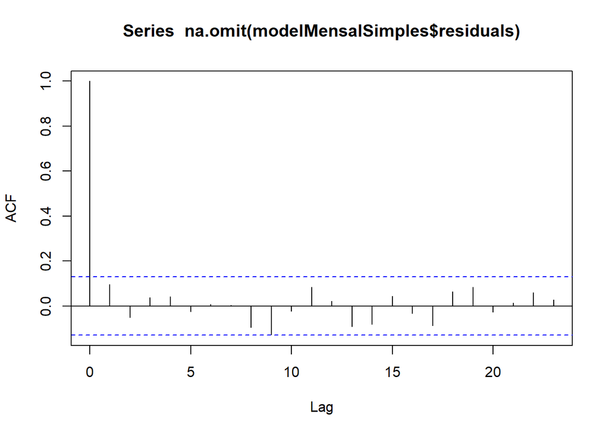

```r
acf(na.omit(modelMensalSimples$residuals), plot = T)
```

Teste de Durbin-Watson

```r
dwtest(modelMensalSimples)
```

```
##
##  Durbin-Watson test
##
## data:  modelMensalSimples
## DW = 1.7654, p-value = 0.038
## alternative hypothesis: true autocorrelation is greater than 0
```

Dummys: Governos

```r
indexBase <- index(baseDadosMensalFillLimpa)
dummys <- matrix(0,nrow = length(indexBase),ncol=2)
rownames(dummys) <- indexBase
colnames(dummys) <- c("Governo_Esquerda","Governo_Direita")
dummys[rownames(dummys) > as.Date("2002-02-01") & rownames(dummys) < as.Date("2016-08-31"),"Governo_Esquerda"] <- 1
dummys[rownames(dummys) > as.Date("2016-08-31"),"Governo_Direita"] <- 1
dummys <- zoo(dummys,order.by = rownames(dummys))
baseLimpaGoverno <- cbind(baseDadosMensalFillLimpa,dummys)
modeloGovernoGap <- lm(IBOV_dif ~ commoditi_dif + RMM + Agreg_Monetario1 - 1 + Governo_Esquerda + Governo_Direita - 1
  ,data=na.omit(baseLimpaGoverno))
summary(modeloGovernoGap)
```

```
##
## Call:
## lm(formula = IBOV_dif ~ commoditi_dif + RMM + Agreg_Monetario1 -
##     1 + Governo_Esquerda + Governo_Direita - 1, data = na.omit(baseLimpaGoverno))
##
## Residuals:
##      Min       1Q   Median       3Q      Max
## -0.38662 -0.04177  0.00052  0.04504  0.20025
##
## Coefficients:
##                   Estimate Std. Error t value Pr(>|t|)
## commoditi_dif    -0.296396   0.123273  -2.404   0.0170 *
## RMM              -0.054683   0.027682  -1.975   0.0495 *
## Agreg_Monetario1  0.240836   0.115795   2.080   0.0387 *
## Governo_Esquerda  0.009412   0.005405   1.741   0.0830 .
## Governo_Direita   0.015374   0.009150   1.680   0.0943 .
## ---
## Signif. codes:  0 '***' 0.001 '**' 0.01 '*' 0.05 '.' 0.1 ' ' 1
##
## Residual standard error: 0.06847 on 222 degrees of freedom
## Multiple R-squared:  0.07729,    Adjusted R-squared:  0.05651
## F-statistic: 3.719 on 5 and 222 DF,  p-value: 0.002976
```

Dummy pandemia

```r
indexBase <- index(baseDadosMensalFillLimpa)
dummys <- matrix(0,nrow = length(indexBase))
rownames(dummys) <- indexBase
colnames(dummys) <- c("Pandemia")
dummys[rownames(dummys) > as.Date("2020-03-01") & rownames(dummys) < as.Date("2020-06-01"),"Pandemia"] <- 1
dummys <- zoo(dummys,order.by = rownames(dummys))
baseLimpaPandemia <- cbind(baseDadosMensalFillLimpa,dummys)
modeloPandemia <- lm(IBOV_dif ~ commoditi_dif + RMM + Pandemia + Agreg_Monetario1 - 1
  ,data=na.omit(baseLimpaPandemia))
summary(modeloPandemia)
```

```
##
## Call:
## lm(formula = IBOV_dif ~ commoditi_dif + RMM + Pandemia + Agreg_Monetario1 -
##     1, data = na.omit(baseLimpaPandemia))
##
## Residuals:
##      Min       1Q   Median       3Q      Max
## -0.36841 -0.02971  0.00791  0.05419  0.20181
##
## Coefficients:
##                  Estimate Std. Error t value Pr(>|t|)
## commoditi_dif    -0.27201    0.12348  -2.203   0.0286 *
## RMM              -0.04293    0.02911  -1.475   0.1416
## Pandemia          0.06115    0.05245   1.166   0.2449
## Agreg_Monetario1  0.27133    0.11576   2.344   0.0200 *
## ---
## Signif. codes:  0 '***' 0.001 '**' 0.01 '*' 0.05 '.' 0.1 ' ' 1
##
## Residual standard error: 0.06898 on 223 degrees of freedom
## Multiple R-squared:  0.05944,    Adjusted R-squared:  0.04257
## F-statistic: 3.523 on 4 and 223 DF,  p-value: 0.008222
```

tratando outliers:

```r
indexBase <- index(baseDadosMensalFillLimpa)
outliers <- c("2002-09-01","2002-10-01","2007-11-01","2007-12-01","2008-01-01","2008-08-01",
              "2008-09-01","2008-11-01","2008-12-01")
dummys <- matrix(0,nrow=length(indexBase),ncol=length(outliers))
colnames(dummys) <- outliers
rownames(dummys) <- indexBase
for (i in outliers){
  dummys[rownames(dummys) == i,i] <- 1
}
baseMensalFillSemOutliers <- cbind(baseDadosMensalFillLimpa,dummys)
paste(outliers,collapse = ' + ')
```

```
## [1] "2002-09-01 + 2002-10-01 + 2007-11-01 + 2007-12-01 + 2008-01-01 + 2008-08-01 + 2008-09-01 + 2008-11-01 + 2008-12-01"
```

```r
modeloSemOutliers <- lm(IBOV_dif ~ commoditi_dif + RMM + Agreg_Monetario1 - 1 + baseMensalFillSemOutliers[,"2002-09-01"] +
  baseMensalFillSemOutliers[,"2002-10-01"] + baseMensalFillSemOutliers[,"2007-11-01"] +
  baseMensalFillSemOutliers[,"2007-12-01"] + baseMensalFillSemOutliers[,"2008-01-01"] +
  baseMensalFillSemOutliers[,"2008-08-01"] + baseMensalFillSemOutliers[,"2008-09-01"] +
  baseMensalFillSemOutliers[,"2008-11-01"] + baseMensalFillSemOutliers[,"2008-12-01"] ,data=baseMensalFillSemOutliers)
summary(modeloSemOutliers)
```

```
##
## Call:
## lm(formula = IBOV_dif ~ commoditi_dif + RMM + Agreg_Monetario1 -
##     1 + baseMensalFillSemOutliers[, "2002-09-01"] + baseMensalFillSemOutliers[,
##     "2002-10-01"] + baseMensalFillSemOutliers[, "2007-11-01"] +
##     baseMensalFillSemOutliers[, "2007-12-01"] + baseMensalFillSemOutliers[,
##     "2008-01-01"] + baseMensalFillSemOutliers[, "2008-08-01"] +
##     baseMensalFillSemOutliers[, "2008-09-01"] + baseMensalFillSemOutliers[,
##     "2008-11-01"] + baseMensalFillSemOutliers[, "2008-12-01"],
##     data = baseMensalFillSemOutliers)
##
## Residuals:
##      Min       1Q   Median       3Q      Max
## -0.36939 -0.02581  0.00935  0.05309  0.15426
##
## Coefficients:
##                                            Estimate Std. Error t value Pr(>|t|)
## commoditi_dif                             -0.303698   0.130399  -2.329  0.02079
## RMM                                       -0.044267   0.034457  -1.285  0.20028
## Agreg_Monetario1                           0.311630   0.117636   2.649  0.00867
## baseMensalFillSemOutliers[, "2002-09-01"] -0.152511   0.069723  -2.187  0.02979
## baseMensalFillSemOutliers[, "2002-10-01"]  0.204811   0.071046   2.883  0.00434
## baseMensalFillSemOutliers[, "2007-11-01"] -0.019259   0.070059  -0.275  0.78366
## baseMensalFillSemOutliers[, "2007-12-01"] -0.001402   0.072183  -0.019  0.98452
## baseMensalFillSemOutliers[, "2008-01-01"] -0.024752   0.070478  -0.351  0.72578
## baseMensalFillSemOutliers[, "2008-08-01"] -0.065935   0.071442  -0.923  0.35709
## baseMensalFillSemOutliers[, "2008-09-01"] -0.082961   0.071762  -1.156  0.24894
## baseMensalFillSemOutliers[, "2008-11-01"] -0.053299   0.069959  -0.762  0.44698
## baseMensalFillSemOutliers[, "2008-12-01"] -0.035108   0.071368  -0.492  0.62327
##
## commoditi_dif                             *
## RMM
## Agreg_Monetario1                          **
## baseMensalFillSemOutliers[, "2002-09-01"] *
## baseMensalFillSemOutliers[, "2002-10-01"] **
## baseMensalFillSemOutliers[, "2007-11-01"]
## baseMensalFillSemOutliers[, "2007-12-01"]
## baseMensalFillSemOutliers[, "2008-01-01"]
## baseMensalFillSemOutliers[, "2008-08-01"]
## baseMensalFillSemOutliers[, "2008-09-01"]
## baseMensalFillSemOutliers[, "2008-11-01"]
## baseMensalFillSemOutliers[, "2008-12-01"]
## ---
## Signif. codes:  0 '***' 0.001 '**' 0.01 '*' 0.05 '.' 0.1 ' ' 1
##
## Residual standard error: 0.06776 on 215 degrees of freedom
##   (11 observations deleted due to missingness)
## Multiple R-squared:  0.1249, Adjusted R-squared:  0.07603
## F-statistic: 2.557 on 12 and 215 DF,  p-value: 0.003514
```

```r
stargazer(modelFillTodos,modelMensalSimples,modeloSemOutliers, type="text",column.labels = c("Modelo Completo",
                                                                                             "Modelo Simples",
                                                                                             "Modelo Simples Sem Outliers"))
```

```
##
## ===================================================================================================================
##                                                                      Dependent variable:
##                                           -------------------------------------------------------------------------
##                                                                           IBOV_dif
##                                              Modelo Completo         Modelo Simples     Modelo Simples Sem Outliers
##                                                    (1)                    (2)                       (3)
## -------------------------------------------------------------------------------------------------------------------
## commoditi_dif                                    -0.290**               -0.255**                 -0.304**
##                                                  (0.128)                (0.123)                   (0.130)
##
## desemprego_dif                                    0.102
##                                                  (0.108)
##
## igp_dif                                           0.023
##                                                  (0.525)
##
## Agreg_Monetario1                                  0.142                 0.295**                  0.312***
##                                                  (0.720)                (0.114)                   (0.118)
##
## Agreg_Monetario2                                  -0.031
##                                                  (0.252)
##
## Agreg_Monetario3                                  0.286
##                                                  (0.946)
##
## producao_fisica_industrial_dif                    0.074
##                                                  (0.076)
##
## jurosEUA_log                                      0.003
##                                                  (0.003)
##
## baseMensalFillSemOutliers[, "2002-09-01"]                                                        -0.153**
##                                                                                                   (0.070)
##
## baseMensalFillSemOutliers[, "2002-10-01"]                                                        0.205***
##                                                                                                   (0.071)
##
## baseMensalFillSemOutliers[, "2007-11-01"]                                                         -0.019
##                                                                                                   (0.070)
```

[output cut: 24 more lines]

```
##
## gap                                               -0.194
##                                                  (0.135)
##
## Constant                                          0.008
##                                                  (0.006)
##
## -------------------------------------------------------------------------------------------------------------------
## Observations                                       227                    227                       227
## R2                                                0.089                  0.054                     0.125
## Adjusted R2                                       0.042                  0.041                     0.076
## Residual Std. Error                          0.068 (df = 215)       0.069 (df = 224)         0.068 (df = 215)
## F Statistic                               1.910** (df = 11; 215) 4.238*** (df = 3; 224)   2.557*** (df = 12; 215)
## ===================================================================================================================
## Note:                                                                                   *p<0.1; **p<0.05; ***p<0.01
```

# Mensal - Gap Linearizado

```r
baseDadosMensalAprox <- baseDados
baseDadosMensalAprox <- baseDadosMensalAprox[c(-1,-2),]
gap <- baseDadosMensalAprox[,'gap']
index_gap <- index(baseDadosMensalAprox[,'gap'])
gap <- na.approx(coredata(gap))
gap <- zoo(gap,order.by = index_gap)
baseDadosMensalAprox$gap <- gap

#A primeira diferença do logaritmo do retorno real da bolsa de valores de São Paulo (RSR);
ibov_dif <- zoo(primeiradiferencalog(baseDadosMensalAprox[,"ibov"]))

#ibovespa de ontem
ibov_ontem <- ibov_dif
ibov_ontem_index <- index(ibov_ontem)
ibov_ontem <- as_tibble(ibov_ontem)
ibov_ontem <- ibov_ontem%>%dplyr::mutate(growth_lag1 = dplyr::lag(ibov_ontem))
ibov_ontem <- zoo(ibov_ontem[,2],order.by = ibov_ontem_index)

#a primeira diferença do logaritmo dos preços das Commodities (COM);
commoditi_dif <- zoo(primeiradiferencalog(baseDadosMensalAprox[,5]))
colnames(baseDadosMensalAprox)[5]
```

```
## [1] "Índice.de.Commodities"
```

```r
#a primeira diferença do logaritmo do desemprego: antiga Pesquisa Mensal do Emprego - PME/ IBGE-19(DES);
desemprego_dif <- zoo(primeiradiferencalog(baseDadosMensalAprox[,"desemprego"]))

#a primeira diferença do logaritmo do IGP (IGP);
igp_dif <- zoo(primeiradiferencalog(baseDadosMensalAprox[,'1.IGPM']))

#a primeira diferença do logaritmo do agregado monetário M1(M1)
M1.1 <- zoo(primeiradiferencalog(baseDadosMensalAprox[,1]))
M1.2 <- zoo(primeiradiferencalog(baseDadosMensalAprox[,2]))
M1.3 <- zoo(primeiradiferencalog(baseDadosMensalAprox[,3]))
colnames(baseDadosMensalAprox)[c(1,2,3)]
```

```
## [1] "Papel.moeda.em.circulação" "Reservas.bancárias"
## [3] "Base.monetária.restrita"
```

```r
#a primeira diferença do logaritmo da produção física industrial dessazonalizada
producao_dif <- zoo(primeiradiferencalog(baseDadosMensalAprox[,4]))

# o logaritmo da taxa de juros dos EUA (EUA).
juros_log <- log(baseDadosMensalAprox[,'FedFunds'])

#o Relative Market Money Rate, construída através da diferença da taxa de juros e a média móvel de 12 meses para trás (RMM);
RMM <- baseDadosMensalAprox[,'FedFunds'] - rollmean(baseDadosMensalAprox[,'FedFunds'],12)
# GAP
gap <- baseDadosMensalAprox[,'gap']

baseDadosMensalAproxLimpa <- merge.zoo(ibov_dif,commoditi_dif,desemprego_dif,igp_dif, M1.1, M1.2, M1.3, producao_dif, juros_log,RMM,ibov_ontem,gap)

colnames(baseDadosMensalAproxLimpa) <- c("IBOV_dif","commoditi_dif","desemprego_dif","igp_dif","Agreg_Monetario1","Agreg_Monetario2","Agreg_Monetario3",
                         "producao_fisica_industrial_dif","jurosEUA_log","RMM","ibov_ontem","gap")
```

Correlacao

```r
cor(na.omit(baseDadosMensalAproxLimpa))
```

```
##                                     IBOV_dif commoditi_dif desemprego_dif
## IBOV_dif                        1.0000000000   -0.12536823  -0.0006254976
## commoditi_dif                  -0.1253682322    1.00000000  -0.1191571473
## desemprego_dif                 -0.0006254976   -0.11915715   1.0000000000
## igp_dif                        -0.0268439507    0.27945957   0.0073082044
## Agreg_Monetario1                0.1120274018    0.19386794  -0.6190209547
## Agreg_Monetario2                0.0804594113    0.07368604  -0.1942690383
## Agreg_Monetario3                0.1219127232    0.17254955  -0.5593157965
## producao_fisica_industrial_dif  0.0048188957   -0.01095344   0.2207348959
## jurosEUA_log                    0.0563994844   -0.09628773  -0.0735683246
## RMM                            -0.1281589552   -0.03979091  -0.0626476981
## ibov_ontem                      0.1060521074   -0.07099775  -0.0371972526
## gap                            -0.1335677858   -0.04922061  -0.1759209318
##                                     igp_dif Agreg_Monetario1 Agreg_Monetario2
## IBOV_dif                       -0.026843951      0.112027402       0.08045941
## commoditi_dif                   0.279459573      0.193867938       0.07368604
## desemprego_dif                  0.007308204     -0.619020955      -0.19426904
## igp_dif                         1.000000000      0.060349058       0.08685389
## Agreg_Monetario1                0.060349058      1.000000000       0.34073211
## Agreg_Monetario2                0.086853894      0.340732113       1.00000000
## Agreg_Monetario3                0.073448146      0.917732790       0.66634867
## producao_fisica_industrial_dif  0.001086623     -0.427980592      -0.03734617
## jurosEUA_log                   -0.095046819      0.012268499       0.03463877
## RMM                            -0.003155480     -0.040396190       0.06114774
## ibov_ontem                     -0.078667719      0.008810398       0.07572848
## gap                            -0.073231046     -0.006726992      -0.03178762
##                                Agreg_Monetario3 producao_fisica_industrial_dif
## IBOV_dif                            0.121912723                    0.004818896
## commoditi_dif                       0.172549549                   -0.010953439
## desemprego_dif                     -0.559315796                    0.220734896
## igp_dif                             0.073448146                    0.001086623
## Agreg_Monetario1                    0.917732790                   -0.427980592
## Agreg_Monetario2                    0.666348673                   -0.037346170
## Agreg_Monetario3                    1.000000000                   -0.361719891
## producao_fisica_industrial_dif     -0.361719891                    1.000000000
## jurosEUA_log                        0.020045898                    0.022449161
## RMM                                -0.009075138                    0.090118586
## ibov_ontem                          0.022713784                    0.145675758
## gap                                -0.020259099                   -0.027203269
##                                jurosEUA_log          RMM   ibov_ontem
```

[output cut: 10 more lines]

```
## ibov_ontem                       0.11255557  0.046137568  1.000000000
## gap                             -0.06637024  0.153340932 -0.098690586
##                                         gap
## IBOV_dif                       -0.133567786
## commoditi_dif                  -0.049220610
## desemprego_dif                 -0.175920932
## igp_dif                        -0.073231046
## Agreg_Monetario1               -0.006726992
## Agreg_Monetario2               -0.031787622
## Agreg_Monetario3               -0.020259099
## producao_fisica_industrial_dif -0.027203269
## jurosEUA_log                   -0.066370236
## RMM                             0.153340932
## ibov_ontem                     -0.098690586
## gap                             1.000000000
```

Modelo Generalista

```r
modelMensalAprox <- lm(IBOV_dif ~ ., data= baseDadosMensalAproxLimpa)
summary(modelMensalAprox)
```

```
##
## Call:
## lm(formula = IBOV_dif ~ ., data = baseDadosMensalAproxLimpa)
##
## Residuals:
##      Min       1Q   Median       3Q      Max
## -0.38441 -0.03370 -0.00287  0.04066  0.19816
##
## Coefficients:
##                                 Estimate Std. Error t value Pr(>|t|)
## (Intercept)                     0.007966   0.006386   1.247   0.2136
## commoditi_dif                  -0.286436   0.128496  -2.229   0.0268 *
## desemprego_dif                  0.101042   0.108294   0.933   0.3518
## igp_dif                         0.055954   0.523438   0.107   0.9150
## Agreg_Monetario1                0.141042   0.720932   0.196   0.8451
## Agreg_Monetario2               -0.026520   0.251908  -0.105   0.9163
## Agreg_Monetario3                0.281511   0.946743   0.297   0.7665
## producao_fisica_industrial_dif  0.074238   0.076116   0.975   0.3305
## jurosEUA_log                    0.003235   0.003265   0.991   0.3229
## RMM                            -0.059065   0.029543  -1.999   0.0468 *
## ibov_ontem                      0.074809   0.067069   1.115   0.2659
## gap                            -0.175399   0.137095  -1.279   0.2021
## ---
## Signif. codes:  0 '***' 0.001 '**' 0.01 '*' 0.05 '.' 0.1 ' ' 1
##
## Residual standard error: 0.06831 on 215 degrees of freedom
##   (11 observations deleted due to missingness)
## Multiple R-squared:  0.08721,    Adjusted R-squared:  0.04051
## F-statistic: 1.867 on 11 and 215 DF,  p-value: 0.04501
```

Anova

```r
anova(modelMensalAprox)
```

|  | Df | Sum Sq | Mean Sq | F value | Pr(>F) |
| --- | --- | --- | --- | --- | --- |
| commoditi_dif | 1 | 1.727397e-02 | 1.727397e-02 | 3.70205253 | 0.05566587 |
| desemprego_dif | 1 | 2.700667e-04 | 2.700667e-04 | 0.05787907 | 0.81010936 |
| igp_dif | 1 | 9.317315e-05 | 9.317315e-05 | 0.01996830 | 0.88775796 |
| Agreg_Monetario1 | 1 | 2.931550e-02 | 2.931550e-02 | 6.28271988 | 0.01293248 |
| Agreg_Monetario2 | 1 | 2.146417e-03 | 2.146417e-03 | 0.46000705 | 0.49834999 |
| Agreg_Monetario3 | 1 | 2.903456e-05 | 2.903456e-05 | 0.00622251 | 0.93719914 |
| producao_fisica_industrial_dif | 1 | 5.731231e-03 | 5.731231e-03 | 1.22828262 | 0.26897954 |
| jurosEUA_log | 1 | 2.182021e-03 | 2.182021e-03 | 0.46763750 | 0.49481240 |
| RMM | 1 | 2.374178e-02 | 2.374178e-02 | 5.08819513 | 0.02509583 |
| ibov_ontem | 1 | 7.427233e-03 | 7.427233e-03 | 1.59175954 | 0.20844199 |

[output cut: 2 more lines]

Um detalhe importante nesse modelo, pelo gap não ter se tornado significativo, ele se tornou um modelo mensal igual ao ultimo, por conta disso não vale a pena analisarmos novamente

# Modelo Semestral

```r
baseSemestral <- baseDados
baseSemestral <- baseSemestral[month(index(baseSemestral)) %in% c(12,6)]

#A primeira diferença do logaritmo do retorno real da bolsa de valores de São Paulo (RSR);
ibov_dif <- zoo(primeiradiferencalog(baseSemestral[,"ibov"]))

#ibovespa de ontem
ibov_ontem <- ibov_dif
ibov_ontem_index <- index(ibov_ontem)
ibov_ontem <- as_tibble(ibov_ontem)
ibov_ontem <- ibov_ontem%>%dplyr::mutate(growth_lag1 = dplyr::lag(ibov_ontem))
ibov_ontem <- zoo(ibov_ontem[,2],order.by = ibov_ontem_index)

#a primeira diferença do logaritmo dos preços das Commodities (COM);
commoditi_dif <- zoo(primeiradiferencalog(baseSemestral[,5]))
colnames(baseSemestral)[5]
```

```
## [1] "Índice.de.Commodities"
```

```r
#a primeira diferença do logaritmo do desemprego: antiga Pesquisa Mensal do Emprego - PME/ IBGE-19(DES);
desemprego_dif <- zoo(primeiradiferencalog(baseSemestral[,"desemprego"]))

#a primeira diferença do logaritmo do IGP (IGP);
igp_dif <- zoo(primeiradiferencalog(baseSemestral[,'1.IGPM']))

#a primeira diferença do logaritmo do agregado monetário M1(M1)
M1.1 <- zoo(primeiradiferencalog(baseSemestral[,1]))
M1.2 <- zoo(primeiradiferencalog(baseSemestral[,2]))
M1.3 <- zoo(primeiradiferencalog(baseSemestral[,3]))
colnames(baseSemestral)[c(1,2,3)]
```

```
## [1] "Papel.moeda.em.circulação" "Reservas.bancárias"
## [3] "Base.monetária.restrita"
```

```r
#a primeira diferença do logaritmo da produção física industrial dessazonalizada
producao_dif <- zoo(primeiradiferencalog(baseSemestral[,4]))

# o logaritmo da taxa de juros dos EUA (EUA).
juros_log <- log(baseSemestral[,'FedFunds'])

#o Relative Market Money Rate, construída através da diferença da taxa de juros e a média móvel de 12 meses para trás (RMM);
RMM <- baseSemestral[,'FedFunds'] - rollmean(baseSemestral[,'FedFunds'],12)
# GAP
gap <- baseSemestral[,'gap']

baseSemestralLimpa <- merge.zoo(ibov_dif,commoditi_dif,desemprego_dif,igp_dif, M1.1, M1.2, M1.3, producao_dif, juros_log,RMM,ibov_ontem,gap)

colnames(baseSemestralLimpa) <- c("IBOV_dif","commoditi_dif","desemprego_dif","igp_dif","Agreg_Monetario1","Agreg_Monetario2","Agreg_Monetario3",
                         "producao_fisica_industrial_dif","jurosEUA_log","RMM","ibov_ontem","gap")
```

Correlação

```r
cor(na.omit(baseSemestralLimpa))
```

```
##                                   IBOV_dif commoditi_dif desemprego_dif
## IBOV_dif                        1.00000000    0.06726289    -0.07770253
## commoditi_dif                   0.06726289    1.00000000    -0.29957587
## desemprego_dif                 -0.07770253   -0.29957587     1.00000000
## igp_dif                        -0.23892292    0.35640258    -0.02417832
## Agreg_Monetario1                0.18590492    0.30449766    -0.83272260
## Agreg_Monetario2                0.59063636    0.28016408    -0.70610516
## Agreg_Monetario3                0.29054137    0.32140549    -0.84343040
## producao_fisica_industrial_dif  0.24366125   -0.25325916     0.59670112
## jurosEUA_log                    0.41656697   -0.12997958    -0.07242125
## RMM                             0.35479230    0.06742896    -0.07051774
## ibov_ontem                     -0.20138855    0.02165950    -0.01497556
## gap                            -0.12096321    0.04636297    -0.33950222
##                                     igp_dif Agreg_Monetario1 Agreg_Monetario2
## IBOV_dif                       -0.238922919       0.18590492       0.59063636
## commoditi_dif                   0.356402577       0.30449766       0.28016408
## desemprego_dif                 -0.024178316      -0.83272260      -0.70610516
## igp_dif                         1.000000000       0.02488461      -0.03947508
## Agreg_Monetario1                0.024884611       1.00000000       0.73580645
## Agreg_Monetario2               -0.039475078       0.73580645       1.00000000
## Agreg_Monetario3                0.009272404       0.98590917       0.83534260
## producao_fisica_industrial_dif -0.080699479      -0.75764343      -0.35622559
## jurosEUA_log                   -0.032944934       0.06761824       0.28168658
## RMM                            -0.057067288       0.04714270       0.28894799
## ibov_ontem                      0.049283977      -0.10396207       0.01636222
## gap                             0.173678722       0.09645989       0.06595995
##                                Agreg_Monetario3 producao_fisica_industrial_dif
## IBOV_dif                            0.290541366                     0.24366125
## commoditi_dif                       0.321405493                    -0.25325916
## desemprego_dif                     -0.843430397                     0.59670112
## igp_dif                             0.009272404                    -0.08069948
## Agreg_Monetario1                    0.985909168                    -0.75764343
## Agreg_Monetario2                    0.835342599                    -0.35622559
## Agreg_Monetario3                    1.000000000                    -0.70976768
## producao_fisica_industrial_dif     -0.709767685                     1.00000000
## jurosEUA_log                        0.116425826                     0.11306247
## RMM                                 0.114914978                     0.09322530
## ibov_ontem                         -0.076830140                     0.10295510
## gap                                 0.089919182                     0.13119217
##                                jurosEUA_log         RMM  ibov_ontem         gap
## IBOV_dif                         0.41656697  0.35479230 -0.20138855 -0.12096321
## commoditi_dif                   -0.12997958  0.06742896  0.02165950  0.04636297
## desemprego_dif                  -0.07242125 -0.07051774 -0.01497556 -0.33950222
## igp_dif                         -0.03294493 -0.05706729  0.04928398  0.17367872
## Agreg_Monetario1                 0.06761824  0.04714270 -0.10396207  0.09645989
## Agreg_Monetario2                 0.28168658  0.28894799  0.01636222  0.06595995
## Agreg_Monetario3                 0.11642583  0.11491498 -0.07683014  0.08991918
## producao_fisica_industrial_dif   0.11306247  0.09322530  0.10295510  0.13119217
## jurosEUA_log                     1.00000000  0.70865776  0.33352450 -0.14649913
## RMM                              0.70865776  1.00000000  0.33777848  0.11616738
## ibov_ontem                       0.33352450  0.33777848  1.00000000  0.13087360
## gap                             -0.14649913  0.11616738  0.13087360  1.00000000
```

Modelo generalista

```r
modelSemestral0 <- lm(IBOV_dif ~ ., data= baseSemestralLimpa)

summary(modelSemestral0)
```

```
##
## Call:
## lm(formula = IBOV_dif ~ ., data = baseSemestralLimpa)
##
## Residuals:
##      Min       1Q   Median       3Q      Max
## -0.15455 -0.05327 -0.02609  0.05157  0.15483
##
## Coefficients:
##                                Estimate Std. Error t value Pr(>|t|)
## (Intercept)                     0.07911    0.04795   1.650  0.11731
## commoditi_dif                   0.25847    0.24946   1.036  0.31466
## desemprego_dif                  0.42511    0.19629   2.166  0.04485 *
## igp_dif                        -1.49359    0.92618  -1.613  0.12523
## Agreg_Monetario1               -5.14014    3.29861  -1.558  0.13759
## Agreg_Monetario2               -0.73312    1.12652  -0.651  0.52389
## Agreg_Monetario3                7.57932    4.50298   1.683  0.11061
## producao_fisica_industrial_dif  1.02960    0.37651   2.735  0.01412 *
## jurosEUA_log                    0.04874    0.02278   2.139  0.04720 *
## RMM                            -0.02331    0.03190  -0.731  0.47491
## ibov_ontem                     -0.33236    0.10961  -3.032  0.00752 **
## gap                             0.24601    0.84223   0.292  0.77375
## ---
## Signif. codes:  0 '***' 0.001 '**' 0.01 '*' 0.05 '.' 0.1 ' ' 1
##
## Residual standard error: 0.09553 on 17 degrees of freedom
##   (11 observations deleted due to missingness)
## Multiple R-squared:  0.8406, Adjusted R-squared:  0.7375
## F-statistic: 8.152 on 11 and 17 DF,  p-value: 8.307e-05
```

Anova

```r
anova(modelSemestral0)
```

|  | Df | Sum Sq | Mean Sq | F value | Pr(>F) |
| --- | --- | --- | --- | --- | --- |
| commoditi_dif | 1 | 0.0044045604 | 0.0044045604 | 0.48264058 | 4.966148e-01 |
| desemprego_dif | 1 | 0.0035425212 | 0.0035425212 | 0.38818051 | 5.415263e-01 |
| igp_dif | 1 | 0.0746848830 | 0.0746848830 | 8.18378046 | 1.082598e-02 |
| Agreg_Monetario1 | 1 | 0.0415235361 | 0.0415235361 | 4.55004399 | 4.779032e-02 |
| Agreg_Monetario2 | 1 | 0.4768614362 | 0.4768614362 | 52.25326926 | 1.410579e-06 |
| Agreg_Monetario3 | 1 | 0.0028843759 | 0.0028843759 | 0.31606262 | 5.813214e-01 |
| producao_fisica_industrial_dif | 1 | 0.0977150436 | 0.0977150436 | 10.70736716 | 4.491515e-03 |
| jurosEUA_log | 1 | 0.0239176883 | 0.0239176883 | 2.62083974 | 1.238702e-01 |
| RMM | 1 | 0.0086801349 | 0.0086801349 | 0.95114721 | 3.431020e-01 |
| ibov_ontem | 1 | 0.0834006101 | 0.0834006101 | 9.13882777 | 7.668209e-03 |

[output cut: 2 more lines]

```r
modelSemestral <- lm(IBOV_dif ~ igp_dif + Agreg_Monetario1 + Agreg_Monetario2 + producao_fisica_industrial_dif + ibov_ontem,
                     data=baseSemestralLimpa)

summary(modelSemestral)
```

```
##
## Call:
## lm(formula = IBOV_dif ~ igp_dif + Agreg_Monetario1 + Agreg_Monetario2 +
##     producao_fisica_industrial_dif + ibov_ontem, data = baseSemestralLimpa)
##
## Residuals:
##      Min       1Q   Median       3Q      Max
## -0.38358 -0.08358 -0.00613  0.09302  0.43959
##
## Coefficients:
##                                Estimate Std. Error t value Pr(>|t|)
## (Intercept)                     0.04692    0.04309   1.089 0.284325
## igp_dif                        -0.68830    0.80023  -0.860 0.396119
## Agreg_Monetario1                0.70273    0.29432   2.388 0.023033 *
## Agreg_Monetario2                0.40106    0.24153   1.661 0.106581
## producao_fisica_industrial_dif  1.33415    0.36394   3.666 0.000886 ***
## ibov_ontem                     -0.20772    0.14380  -1.444 0.158324
## ---
## Signif. codes:  0 '***' 0.001 '**' 0.01 '*' 0.05 '.' 0.1 ' ' 1
##
## Residual standard error: 0.1638 on 32 degrees of freedom
##   (2 observations deleted due to missingness)
## Multiple R-squared:  0.3837, Adjusted R-squared:  0.2875
## F-statistic: 3.985 on 5 and 32 DF,  p-value: 0.006361
```

```r
modelSemestral2 <- lm(IBOV_dif ~ desemprego_dif + producao_fisica_industrial_dif + jurosEUA_log + ibov_ontem,
                     data=baseSemestralLimpa)
summary(modelSemestral2)
```

```
##
## Call:
## lm(formula = IBOV_dif ~ desemprego_dif + producao_fisica_industrial_dif +
##     jurosEUA_log + ibov_ontem, data = baseSemestralLimpa)
##
## Residuals:
##      Min       1Q   Median       3Q      Max
## -0.37691 -0.07095 -0.01853  0.06944  0.39316
##
## Coefficients:
##                                Estimate Std. Error t value Pr(>|t|)
## (Intercept)                     0.12930    0.03166   4.085 0.000265 ***
## desemprego_dif                 -0.32608    0.16283  -2.003 0.053493 .
## producao_fisica_industrial_dif  0.85635    0.32949   2.599 0.013871 *
## jurosEUA_log                    0.06022    0.01823   3.304 0.002303 **
## ibov_ontem                     -0.40901    0.14564  -2.808 0.008301 **
## ---
## Signif. codes:  0 '***' 0.001 '**' 0.01 '*' 0.05 '.' 0.1 ' ' 1
##
## Residual standard error: 0.1581 on 33 degrees of freedom
##   (2 observations deleted due to missingness)
## Multiple R-squared:  0.4079, Adjusted R-squared:  0.3362
## F-statistic: 5.684 on 4 and 33 DF,  p-value: 0.001356
```

Modelo generalista sem alfa

```r
modelSemestral0SemAlfa <- lm(IBOV_dif ~ . -1, data= baseSemestralLimpa)

summary(modelSemestral0SemAlfa)
```

```
##
## Call:
## lm(formula = IBOV_dif ~ . - 1, data = baseSemestralLimpa)
##
## Residuals:
##       Min        1Q    Median        3Q       Max
## -0.131502 -0.044017  0.007865  0.064900  0.161701
##
## Coefficients:
##                                 Estimate Std. Error t value Pr(>|t|)
## commoditi_dif                   0.097568   0.240345   0.406 0.689566
## desemprego_dif                  0.393132   0.204465   1.923 0.070483 .
## igp_dif                        -0.442879   0.703949  -0.629 0.537164
## Agreg_Monetario1               -5.247318   3.452151  -1.520 0.145878
## Agreg_Monetario2               -0.988690   1.167983  -0.846 0.408391
## Agreg_Monetario3                8.162295   4.698955   1.737 0.099461 .
## producao_fisica_industrial_dif  1.359145   0.334092   4.068 0.000722 ***
## jurosEUA_log                    0.026793   0.019359   1.384 0.183284
## RMM                             0.001364   0.029495   0.046 0.963633
## ibov_ontem                     -0.288085   0.111240  -2.590 0.018493 *
## gap                            -0.478379   0.752351  -0.636 0.532879
## ---
## Signif. codes:  0 '***' 0.001 '**' 0.01 '*' 0.05 '.' 0.1 ' ' 1
##
## Residual standard error: 0.1 on 18 degrees of freedom
##   (11 observations deleted due to missingness)
## Multiple R-squared:  0.8275, Adjusted R-squared:  0.7221
## F-statistic: 7.851 on 11 and 18 DF,  p-value: 7.71e-05
```

Comparação

```r
stargazer(modelSemestral0,modelSemestral0SemAlfa,modelSemestral,modelSemestral2,type="text",title="Comparando Modelos Semestrais",
                                 column.labels = c("Modelo 0","Modelo 0 Sem Alfa","Modelo pelo Anova","Modelo Var. Significativas"))
```

```
##
## Comparando Modelos Semestrais
## =============================================================================================================================
##                                                                     Dependent variable:
##                                ----------------------------------------------------------------------------------------------
##                                                                           IBOV_dif
##                                       Modelo 0          Modelo 0 Sem Alfa      Modelo pelo Anova   Modelo Var. Significativas
##                                         (1)                    (2)                    (3)                     (4)
## -----------------------------------------------------------------------------------------------------------------------------
## commoditi_dif                          0.258                  0.098
##                                       (0.249)                (0.240)
##
## desemprego_dif                        0.425**                 0.393*                                        -0.326*
##                                       (0.196)                (0.204)                                        (0.163)
##
## igp_dif                                -1.494                 -0.443                -0.688
##                                       (0.926)                (0.704)                (0.800)
##
## Agreg_Monetario1                       -5.140                 -5.247                0.703**
##                                       (3.299)                (3.452)                (0.294)
##
## Agreg_Monetario2                       -0.733                 -0.989                 0.401
##                                       (1.127)                (1.168)                (0.242)
##
## Agreg_Monetario3                       7.579                  8.162*
##                                       (4.503)                (4.699)
##
## producao_fisica_industrial_dif        1.030**                1.359***              1.334***                 0.856**
##                                       (0.377)                (0.334)                (0.364)                 (0.329)
##
## jurosEUA_log                          0.049**                 0.027                                         0.060***
##                                       (0.023)                (0.019)                                        (0.018)
##
## RMM                                    -0.023                 0.001
##                                       (0.032)                (0.029)
##
## ibov_ontem                           -0.332***               -0.288**               -0.208                 -0.409***
##                                       (0.110)                (0.111)                (0.144)                 (0.146)
##
## gap                                    0.246                  -0.478
##                                       (0.842)                (0.752)
##
## Constant                               0.079                                         0.047                  0.129***
##                                       (0.048)                                       (0.043)                 (0.032)
##
## -----------------------------------------------------------------------------------------------------------------------------
## Observations                             29                     29                    38                       38
## R2                                     0.841                  0.828                  0.384                   0.408
## Adjusted R2                            0.738                  0.722                  0.287                   0.336
## Residual Std. Error               0.096 (df = 17)        0.100 (df = 18)        0.164 (df = 32)         0.158 (df = 33)
## F Statistic                    8.152*** (df = 11; 17) 7.851*** (df = 11; 18) 3.985*** (df = 5; 32)   5.684*** (df = 4; 33)
## =============================================================================================================================
## Note:                                                                                             *p<0.1; **p<0.05; ***p<0.01
```

Decidi não alterar o modelo e ir com um semestral sem alfa.

```r
modelSemestral <- modelSemestral0SemAlfa
```

Teste reset - Erros normalizados com media 0

```r
reset(modelSemestral)
```

```
##
##  RESET test
##
## data:  modelSemestral
## RESET = 0.43766, df1 = 2, df2 = 16, p-value = 0.653
```

```r
vif(modelSemestral)
```

```
##                  commoditi_dif                 desemprego_dif
##                       1.408111                       5.487461
##                        igp_dif               Agreg_Monetario1
##                       1.858877                     737.034187
##               Agreg_Monetario2               Agreg_Monetario3
##                      65.521930                    1153.919452
## producao_fisica_industrial_dif                   jurosEUA_log
##                       3.619480                       3.008738
##                            RMM                     ibov_ontem
##                       2.833518                       1.250356
##                            gap
##                       1.889118
```

Criando um modelo tentando reduzir o vif, bem sucedido, sacrifiquei R2 para ganhar significancia.

```r
modelSemestralSemInflacaoDeVariavel <- lm(IBOV_dif ~ Agreg_Monetario3 + producao_fisica_industrial_dif -1, data=na.omit(baseSemestralLimpa))
summary(modelSemestralSemInflacaoDeVariavel)
```

```
##
## Call:
## lm(formula = IBOV_dif ~ Agreg_Monetario3 + producao_fisica_industrial_dif -
##     1, data = na.omit(baseSemestralLimpa))
##
## Residuals:
##      Min       1Q   Median       3Q      Max
## -0.28175 -0.08161 -0.02895  0.08417  0.27009
##
## Coefficients:
##                                Estimate Std. Error t value Pr(>|t|)
## Agreg_Monetario3                 1.3078     0.2535   5.159 1.99e-05 ***
## producao_fisica_industrial_dif   1.5212     0.3218   4.726 6.35e-05 ***
## ---
## Signif. codes:  0 '***' 0.001 '**' 0.01 '*' 0.05 '.' 0.1 ' ' 1
##
## Residual standard error: 0.1359 on 27 degrees of freedom
## Multiple R-squared:  0.5223, Adjusted R-squared:  0.4869
## F-statistic: 14.76 on 2 and 27 DF,  p-value: 4.661e-05
```

Rodando para ver se corrigi o VIF

```r
modelSemestral <- modelSemestralSemInflacaoDeVariavel
vif(modelSemestral)
```

```
##               Agreg_Monetario3 producao_fisica_industrial_dif
##                       1.819238                       1.819238
```

Um anova.

```r
anova(modelSemestral)
```

|  | Df | Sum Sq | Mean Sq | F value | Pr(>F) |
| --- | --- | --- | --- | --- | --- |
| Agreg_Monetario3 | 1 | 0.1326033 | 0.13260333 | 7.182481 | 1.239026e-02 |
| producao_fisica_industrial_dif | 1 | 0.4124245 | 0.41242452 | 22.339043 | 6.353682e-05 |
| Residuals | 27 | 0.4984753 | 0.01846205 | NA | NA |

Graficos a serem analisados

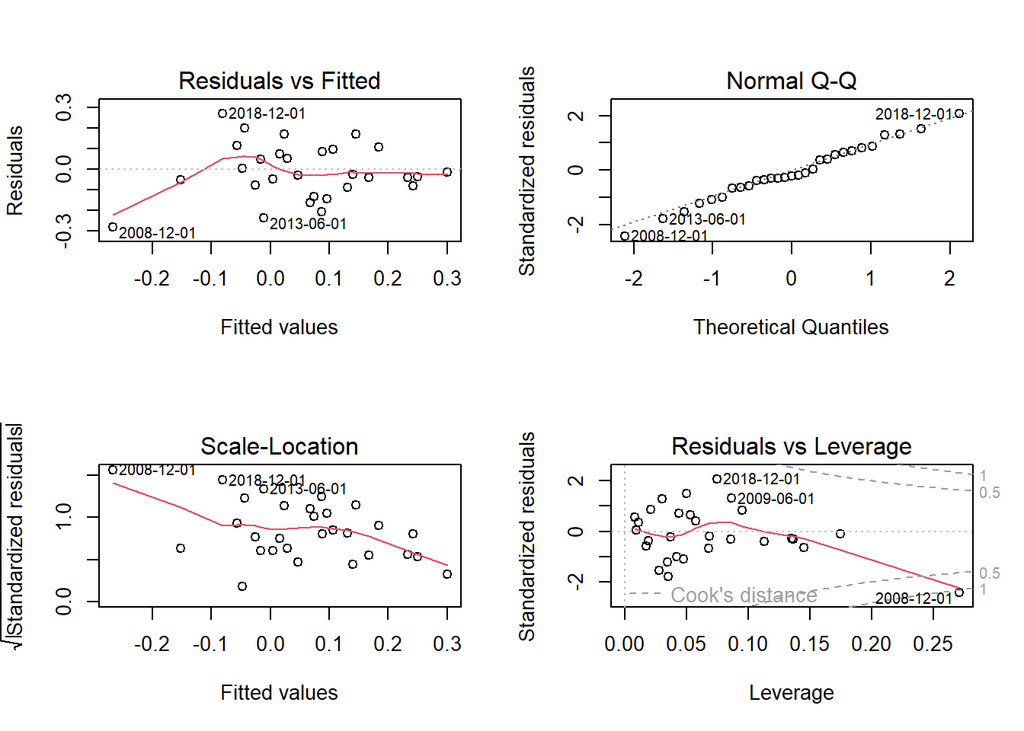

```r
par(mfrow=c(2,2))
plot(modelSemestral)
```

```r
par(mfrow=c(1,1))
```

Elementos da diagonal de H:

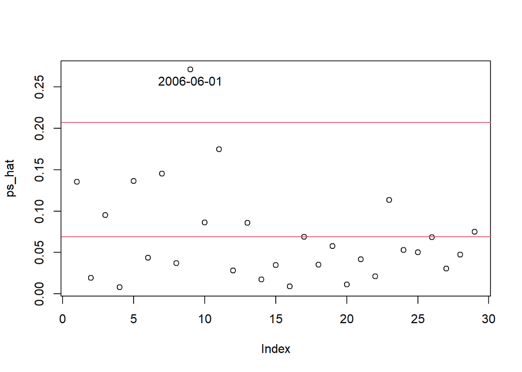

```r
ps_hat <- hatvalues(modelSemestral)
plot(ps_hat)
abline(h=c(1,3)*mean(ps_hat), col=2)
id <- which(ps_hat>3 * mean(ps_hat))
text(id, ps_hat[id], index(baseSemestralLimpa)[id], pos=1, xpd=TRUE)
```

Testes de diagnóstico:

```r
summary(influence.measures(modelSemestral))
```

```
## Potentially influential observations of
##   lm(formula = IBOV_dif ~ Agreg_Monetario3 + producao_fisica_industrial_dif -      1, data = na.omit(baseSemestralLimpa)) :
##
##            dfb.A_M3 dfb.p___ dffit   cov.r   cook.d  hat
## 2004-12-01 -0.11    -0.07    -0.11    1.24_*  0.01    0.14
## 2006-12-01 -0.12    -0.06    -0.12    1.24_*  0.01    0.14
## 2008-12-01  0.71     1.58_*  -1.64_*  0.90    1.10_*  0.27_*
## 2009-12-01 -0.05    -0.04    -0.05    1.31_*  0.00    0.17
```

teste de Jarque-Bera:

```r
e <- resid(modelSemestral)
jarqueberaTest(e)
```

```
##
## Title:
##  Jarque - Bera Normalality Test
##
## Test Results:
##   STATISTIC:
##     X-squared: 0.2198
##   P VALUE:
##     Asymptotic p Value: 0.8959
##
## Description:
##  Thu Nov 24 22:55:39 2022 by user: diogo
```

Teste de Breusch-Pagan:

```r
bptest(modelSemestral)
```

```
##
##  studentized Breusch-Pagan test
##
## data:  modelSemestral
## BP = 7.4162, df = 1, p-value = 0.006464
```

Teste de White

```r
white(modelSemestral, interactions = TRUE)
```

```
## Intercept included in auxiliary design matrix
```

| statistic | p.value | parameter | method | alternative |
| --- | --- | --- | --- | --- |
| 12.43152 | 0.02933022 | 5 | White's Test | greater |

Teste de Goldfeld e Quandt

```r
gqtest(modelSemestral, data=baseSemestralLimpa)
```

```
##
##  Goldfeld-Quandt test
##
## data:  modelSemestral
## GQ = 1.5391, df1 = 13, df2 = 12, p-value = 0.2315
## alternative hypothesis: variance increases from segment 1 to 2
```

Erros padrão de White

Matriz de covariância de White:

```r
vcovHC(modelSemestral)
```

```
##                                Agreg_Monetario3 producao_fisica_industrial_dif
## Agreg_Monetario3                     0.04791295                     0.09221479
## producao_fisica_industrial_dif       0.09221479                     0.28132155
```

Ver correlacao serial

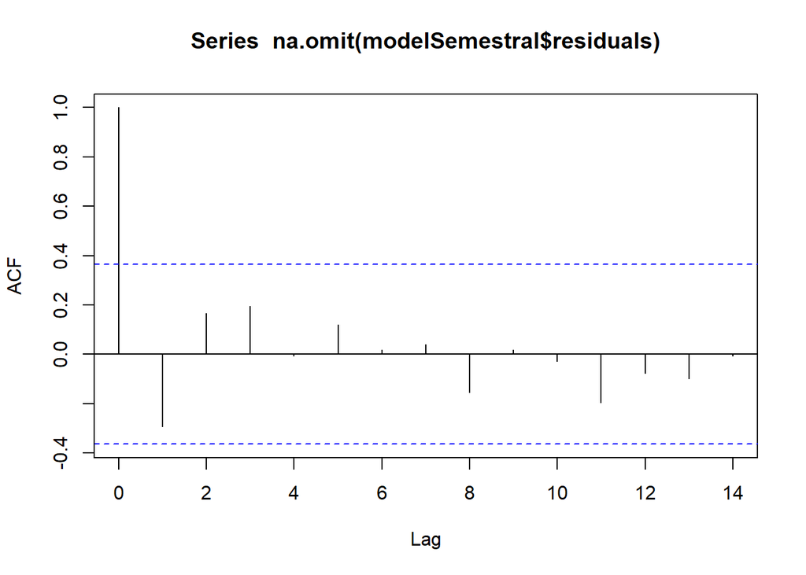

```r
acf(na.omit(modelSemestral$residuals), plot = T)
```

```r
dwtest(modelSemestral)
```

```
##
##  Durbin-Watson test
##
## data:  modelSemestral
## DW = 2.4118, p-value = 0.9328
## alternative hypothesis: true autocorrelation is greater than 0
```

Dummys: Governos

```r
indexBase <- index(baseSemestralLimpa)
length(indexBase)
```

```
## [1] 40
```

```r
dummys <- matrix(0,nrow = length(indexBase),ncol=2)
rownames(dummys) <- indexBase
colnames(dummys) <- c("Governo_Esquerda","Governo_Direita")
dummys[rownames(dummys) > as.Date("2002-02-01") & rownames(dummys) < as.Date("2016-08-31"),"Governo_Esquerda"] <- 1
dummys[rownames(dummys) > as.Date("2016-08-31"),"Governo_Direita"] <- 1
dummys <- zoo(dummys,order.by = rownames(dummys))
baseLimpaGoverno <- cbind(baseSemestralLimpa,dummys)
modeloGovernoGap <- lm(IBOV_dif ~ Agreg_Monetario3 + producao_fisica_industrial_dif  - 1 + Governo_Esquerda + Governo_Direita - 1
  ,data=na.omit(baseLimpaGoverno))
summary(modeloGovernoGap)
```

```
##
## Call:
## lm(formula = IBOV_dif ~ Agreg_Monetario3 + producao_fisica_industrial_dif -
##     1 + Governo_Esquerda + Governo_Direita - 1, data = na.omit(baseLimpaGoverno))
##
## Residuals:
##       Min        1Q    Median        3Q       Max
## -0.232480 -0.067526 -0.002859  0.109720  0.197158
##
## Coefficients:
##                                Estimate Std. Error t value Pr(>|t|)
## Agreg_Monetario3                1.42317    0.28209   5.045 3.32e-05 ***
## producao_fisica_industrial_dif  1.65011    0.33414   4.938 4.37e-05 ***
## Governo_Esquerda               -0.03571    0.03067  -1.164    0.255
## Governo_Direita                 0.07929    0.06009   1.320    0.199
## ---
## Signif. codes:  0 '***' 0.001 '**' 0.01 '*' 0.05 '.' 0.1 ' ' 1
##
## Residual standard error: 0.1327 on 25 degrees of freedom
## Multiple R-squared:  0.5778, Adjusted R-squared:  0.5103
## F-statistic: 8.554 on 4 and 25 DF,  p-value: 0.0001714
```

Dummy pandemia

```r
indexBase <- index(baseSemestralLimpa)
dummys <- matrix(0,nrow = length(indexBase))
rownames(dummys) <- indexBase
colnames(dummys) <- c("Pandemia")
dummys[rownames(dummys) > as.Date("2020-03-01") & rownames(dummys) < as.Date("2022-1-01"),"Pandemia"] <- 1
dummys <- zoo(dummys,order.by = rownames(dummys))
baseLimpaPandemia <- cbind(baseSemestralLimpa,dummys)
modeloPandemia <- lm(IBOV_dif ~ Agreg_Monetario3 + producao_fisica_industrial_dif  - 1 + Pandemia
  ,data=na.omit(baseLimpaPandemia))
summary(modeloPandemia)
```

```
##
## Call:
## lm(formula = IBOV_dif ~ Agreg_Monetario3 + producao_fisica_industrial_dif -
##     1 + Pandemia, data = na.omit(baseLimpaPandemia))
##
## Residuals:
##      Min       1Q   Median       3Q      Max
## -0.28175 -0.08161 -0.02895  0.08417  0.27009
##
## Coefficients: (1 not defined because of singularities)
##                                Estimate Std. Error t value Pr(>|t|)
## Agreg_Monetario3                 1.3078     0.2535   5.159 1.99e-05 ***
## producao_fisica_industrial_dif   1.5212     0.3218   4.726 6.35e-05 ***
## Pandemia                             NA         NA      NA       NA
## ---
## Signif. codes:  0 '***' 0.001 '**' 0.01 '*' 0.05 '.' 0.1 ' ' 1
##
## Residual standard error: 0.1359 on 27 degrees of freedom
## Multiple R-squared:  0.5223, Adjusted R-squared:  0.4869
## F-statistic: 14.76 on 2 and 27 DF,  p-value: 4.661e-05
```